# FEMALE REPRESENTATION IN POLITICS

## WE WILL BE CHECKING THE FEMALE PARTICIPATION IN LOK SABHA ELECTIONS.

## Group 18 - Politics

### Group Members: Purav Patel, Pavithra Kothacheruvu Ravi, Sanyuja Kadam

## Objective of the Proposed Research

In this project we are studying about the participation of women candidates in the Indian general elections. We are looking into how females are represented in the elections and what are the factors that affect the chosen candidates. We will also be identifying probable female candidates winning in a state and the party associated with her. We will be looking into various datapoints in the dataset which will help us determine the chances of winning for a female candidate and various aspects related to the candidate.

Our stakeholder for this research is a political party looking to add strong and influential female candidates for the upcoming elections to their party. This research will provide them with key insights on the participating candidates and will ease their recruitment process to maximize their chances of being elected.

The data used in this research consists of Candidate name, Current party name, Criminal records associated with that candidate, Age, Total assets, Constituency, Age, Previous winning record and finally Gender.

## Data Exploration

The data set is taken from https://www.kaggle.com/code/themlphdstudent/2004-lok-sabha-election-eda-and-winner-prediction/data?select=LokSabha2019.csv

### 2.1) Understanding the dataset

We have 4 csv files of the Indian Lok Sabha election data of all the candidates for the years 2004, 2009, 2014, 2019.

```r
data2004 <- read.csv('LokSabha2004.csv')
```

```r
data2009 <- read.csv('LokSabha2009.csv')
```

```r
data2014 <- read.csv('LokSabha2014.csv')
```

```r
data2019 <- read.csv('LokSabha2019.csv')
```

```r
df2004 <- as.data.frame(data2004)
df2009 <- as.data.frame(data2009)
df2014 <- as.data.frame(data2014)
df2019 <- as.data.frame(data2019)
```

## 2.2) Listing the Column Names

Let's check the first 5 rows of all the above csv files. All the files contain 10 columns such as Candidate, Party, Age, Gender, Lialibities etc. We can check the column names below for all the above csv files.

```r
names(data2004)
names(data2009)
names(data2014)
names(data2019)
```

1. 'Candidate'

2. 'Party'

3. 'Criminal.Cases'

4. 'Education'

5. 'Age'

6. 'Total.Assets'

7. 'Constituency'

8. 'Liabilities'

9. 'Winner'

10. 'Gender'

1. 'Candidate'

2. 'Party'

3. 'Criminal.Cases'

4. 'Education'

5. 'Age'

6. 'Total.Assets'

7. 'Constituency'

8. 'Liabilities'

9. 'Winner'

10. 'Gender'

1. 'Candidate'

2. 'Party'

3. 'Criminal.Cases'

4. 'Education'

5. 'Age'

6. 'Total.Assets'

7. 'Constituency'

8. 'Liabilities'

9. 'Winner'

10. 'Gender'

1. 'Candidate'

2. 'Party'

3. 'Criminal.Cases'

4. 'Education'

5. 'Age'

6. 'Total.Assets'

7. 'Constituency'

8. 'Liabilities'

9. 'Winner'

10. 'Gender'

### 2.3) View sample data

```r
head(data2004[1:5,])
```

A data.frame: 5 × 10

|  | Candidate <chr> | Party <chr> | Criminal.Cases <int> | Education <chr> | Age <int> | Total.Assets <dbl> | Constituency <chr> | Liabilities <int> | Winner <int> | Gender <chr> |
| --- | --- | --- | --- | --- | --- | --- | --- | --- | --- | --- |
| 1 | Manoranjan Bhakta | INC | 0 | Post Graduate | 65 | 5926740 | Andaman & Nicobar Islands | 272061 | 1 | M |
| 2 | A K Biswas | BSP | 0 | Graduate | 61 | 7876500 | Andaman & Nicobar Islands | 65000 | 0 | M |
| 3 | Asit Baran Dutta | IND | 0 | Graduate | 50 | 3070000 | Andaman & Nicobar Islands | 0 | 0 | M |
| 4 | Bishnu Pada Ray | BJP | 0 | Graduate | 54 | 1250619 | Andaman & Nicobar Islands | 128710 | 0 | M |
| 5 | Deepak Biswas | IND | 0 | Not Given | 28 | 3000 | Andaman & Nicobar Islands | 0 | 0 | M |

```r
head(data2009[1:5,])
```

A data.frame: 5 × 10

|  | Candidate <chr> | Party <chr> | Criminal.Cases <int> | Education <chr> | Age <int> | Total.Assets <dbl> | Constituency <chr> | Liabilities <int> | Winner <int> | Gender <chr> |
| --- | --- | --- | --- | --- | --- | --- | --- | --- | --- | --- |
| 1 | Shri Bishnu Pada Ray | BJP | 1 | Graduate | 59 | 1241034 | Andaman & Nicobar Islands | 0 | 0 | M |
| 2 | Shri P. R. Ganeshan | RJD | 0 | Not Given | 71 | 329563 | Andaman & Nicobar Islands | 0 | 0 | M |
| 3 | Shri Pradeep Kumar Ekka | JDP | 0 | Others | 37 | 410000 | Andaman & Nicobar Islands | 0 | 0 | M |
| 4 | Shri T. Ali | IND | 0 | 12th Pass | 37 | 445957 | Andaman & Nicobar Islands | 296000 | 0 | M |
| 5 | Shri Tapan Kumar Bepari | CPM | 0 | Post Graduate | 52 | 3986000 | Andaman & Nicobar Islands | 0 | 0 | M |

```r
head(data2014[1:5,])
```

A data.frame: 5 × 10

|  | Candidate <chr> | Party <chr> | Criminal.Cases <int> | Education <chr> | Age <int> | Total.Assets <dbl> | Constituency <chr> | Liabilities <dbl> | Winner <dbl> | Gender <chr> |
| --- | --- | --- | --- | --- | --- | --- | --- | --- | --- | --- |
| 1 | Bishnu Pada Ray | BJP | 1 | Graduate | 64 | 5658980 | ANDAMAN AND NICOBAR ISLANDS | 175115 | 0 | M |
| 2 | A Pandian | AIFB | 0 | 12th Pass | 41 | 859410 | ANDAMAN AND NICOBAR ISLANDS | 350000 | 0 | M |
| 3 | Anita Mondal | AITC | 1 | Graduate | 48 | 5471073 | ANDAMAN AND NICOBAR ISLANDS | 6000 | 0 | M |
| 4 | C G Saji Kumar | IND | 0 | 12th Pass | 41 | 50000 | ANDAMAN AND NICOBAR ISLANDS | 0 | 0 | M |
| 5 | Gaur Chandra Majumder | BSP | 0 | Graduate | 47 | 3192819 | ANDAMAN AND NICOBAR ISLANDS | 688689 | 0 | M |

```r
head(data2019[1:5,])
```

A data.frame: 5 × 10

|  | Candidate <chr> | Party <chr> | Criminal.Cases <int> | Education <chr> | Age <int> | Total.Assets <dbl> | Constituency <chr> | Liabilities <int> | Winner <dbl> | Gender <chr> |
| --- | --- | --- | --- | --- | --- | --- | --- | --- | --- | --- |
| 1 | Kuldeep Rai Sharma | INC | 0 | Graduate Professional | 52 | 132233012 | Andaman And Nicobar Islands | 80450870 | 1 | M |
| 2 | Ayan Mandal | AITC | 0 | Graduate | 30 | 7270440 | Andaman And Nicobar Islands | 1500000 | 0 | M |
| 3 | C G Saji Kumar | All India Hindustan Congress Party | 0 | 12th Pass | 48 | 120000 | Andaman And Nicobar Islands | 0 | 0 | M |
| 4 | C U Rasheed | IND | 0 | 12th Pass | 34 | 202808 | Andaman And Nicobar Islands | 1700000 | 0 | M |
| 5 | Gour Chandra Majumder | IND | 0 | Graduate | 52 | 6062000 | Andaman And Nicobar Islands | 0 | 0 | M |

```r
dim(data2004)
dim(data2009)
dim(data2014)
dim(data2019)
```

1. 3642

2. 10

1. 7920

2. 10

1. 8484

2. 10

1. 7968

2. 10

### 2.4) Structure & Summary of the dataset

Let us understand the types of columns what sort of data do they store. From the below data we can see that the column Total Assets contains Numeric data and the column Candidate contains Character type data.

```r
str(data2004)
str(data2009)
str(data2014)
str(data2019)
```

```
'data.frame':	3642 obs. of  10 variables:
 $ Candidate     : chr  "Manoranjan Bhakta" "A K Biswas" "Asit Baran Dutta" "Bishnu Pada Ray" ...
 $ Party         : chr  "INC" "BSP" "IND" "BJP" ...
 $ Criminal.Cases: int  0 0 0 0 0 0 0 1 0 0 ...
 $ Education     : chr  "Post Graduate" "Graduate" "Graduate" "Graduate" ...
 $ Age           : int  65 61 50 54 28 66 37 51 65 49 ...
 $ Total.Assets  : num  5926740 7876500 3070000 1250619 3000 ...
 $ Constituency  : chr  "Andaman & Nicobar Islands" "Andaman & Nicobar Islands" "Andaman & Nicobar Islands" "Andaman & Nicobar Islands" ...
 $ Liabilities   : int  272061 65000 0 128710 0 67070 0 73878 0 188000 ...
 $ Winner        : int  1 0 0 0 0 0 0 0 0 0 ...
 $ Gender        : chr  "M" "M" "M" "M" ...
'data.frame':	7920 obs. of  10 variables:
 $ Candidate     : chr  "Shri Bishnu Pada Ray" "Shri P. R. Ganeshan" "Shri Pradeep Kumar Ekka" "Shri T. Ali" ...
 $ Party         : chr  "BJP" "RJD" "JDP" "IND" ...
 $ Criminal.Cases: int  1 0 0 0 0 0 1 0 0 1 ...
```

[output cut: 29 more lines]

Let's understand our dataset with a statistical point. The below code will help us understand what are the different Mean, Median of our numeric columns.

```r
summary(data2004)
summary(data2009)
summary(data2014)
summary(data2019)
```

```
  Candidate            Party           Criminal.Cases     Education
 Length:3642        Length:3642        Min.   : 0.0000   Length:3642
 Class :character   Class :character   1st Qu.: 0.0000   Class :character
 Mode  :character   Mode  :character   Median : 0.0000   Mode  :character
                                       Mean   : 0.3734
                                       3rd Qu.: 0.0000
                                       Max.   :36.0000

      Age         Total.Assets       Constituency        Liabilities
 Min.   : 0.00   Min.   :1.000e+02   Length:3642        Min.   :        0
 1st Qu.:37.00   1st Qu.:2.000e+05   Class :character   1st Qu.:        0
 Median :46.00   Median :1.043e+06   Mode  :character   Median :        0
 Mean   :46.13   Mean   :1.235e+07                      Mean   :   645453
 3rd Qu.:55.75   3rd Qu.:4.526e+06                      3rd Qu.:    90000
 Max.   :94.00   Max.   :1.522e+10                      Max.   :633300000
                 NA's   :260
     Winner          Gender
 Min.   :0.0000   Length:3642
 1st Qu.:0.0000   Class :character
 Median :0.0000   Mode  :character
 Mean   :0.1065
 3rd Qu.:0.0000
 Max.   :1.0000
```

```
  Candidate            Party           Criminal.Cases     Education
 Length:7920        Length:7920        Min.   : 0.0000   Length:7920
 Class :character   Class :character   1st Qu.: 0.0000   Class :character
 Mode  :character   Mode  :character   Median : 0.0000   Mode  :character
                                       Mean   : 0.3734
                                       3rd Qu.: 0.0000
                                       Max.   :46.0000

      Age         Total.Assets       Constituency        Liabilities
 Min.   : 0.00   Min.   :2.000e+00   Length:7920        Min.   :        0
 1st Qu.:37.00   1st Qu.:2.030e+05   Class :character   1st Qu.:        0
 Median :45.00   Median :1.106e+06   Mode  :character   Median :        0
 Mean   :45.92   Mean   :1.855e+07                      Mean   :   777475
 3rd Qu.:54.00   3rd Qu.:5.345e+06                      3rd Qu.:    85000
 Max.   :88.00   Max.   :1.978e+10                      Max.   :375816032
                 NA's   :417
     Winner           Gender
 Min.   :0.00000   Length:7920
 1st Qu.:0.00000   Class :character
 Median :0.00000   Mode  :character
 Mean   :0.04571
 3rd Qu.:0.00000
 Max.   :1.00000
```

```
  Candidate            Party           Criminal.Cases      Education
 Length:8484        Length:8484        Min.   :  0.0000   Length:8484
 Class :character   Class :character   1st Qu.:  0.0000   Class :character
 Mode  :character   Mode  :character   Median :  0.0000   Mode  :character
                                       Mean   :  0.5507
                                       3rd Qu.:  0.0000
                                       Max.   :382.0000

      Age         Total.Assets       Constituency        Liabilities
 Min.   : 0.00   Min.   :3.500e+01   Length:8484        Min.   :0.000e+00
 1st Qu.:38.00   1st Qu.:4.725e+05   Class :character   1st Qu.:0.000e+00
 Median :46.00   Median :2.545e+06   Mode  :character   Median :0.000e+00
 Mean   :46.76   Mean   :5.005e+07                      Mean   :3.951e+06
 3rd Qu.:56.00   3rd Qu.:1.167e+07                      3rd Qu.:4.000e+05
 Max.   :93.00   Max.   :7.710e+10                      Max.   :2.218e+09
                 NA's   :78
     Winner     Gender
 Min.   :0   Length:8484
 1st Qu.:0   Class :character
 Median :0   Mode  :character
 Mean   :0
 3rd Qu.:0
 Max.   :0
```

```
  Candidate            Party           Criminal.Cases      Education
 Length:7968        Length:7968        Min.   :  0.0000   Length:7968
 Class :character   Class :character   1st Qu.:  0.0000   Class :character
 Mode  :character   Mode  :character   Median :  0.0000   Mode  :character
                                       Mean   :  0.5732
                                       3rd Qu.:  0.0000
                                       Max.   :240.0000

      Age         Total.Assets       Constituency        Liabilities
 Min.   : 0.00   Min.   :9.000e+00   Length:7968        Min.   :0.000e+00
 1st Qu.:38.00   1st Qu.:5.040e+05   Class :character   1st Qu.:0.000e+00
 Median :46.00   Median :2.752e+06   Mode  :character   Median :0.000e+00
 Mean   :46.92   Mean   :4.201e+07                      Mean   :5.576e+06
 3rd Qu.:56.00   3rd Qu.:1.309e+07                      3rd Qu.:6.190e+05
 Max.   :90.00   Max.   :1.108e+10                      Max.   :1.548e+09
                 NA's   :60
     Winner           Gender
 Min.   :0.00000   Length:7968
 1st Qu.:0.00000   Class :character
 Median :0.00000   Mode  :character
 Mean   :0.03828
 3rd Qu.:0.00000
 Max.   :1.00000
```

## 3) Data Cleaning

```r
install.packages('dplyr')
```

```r
library(dplyr)
```

3.1)Renaming Columns

Lets rename some columns of our datasets. We are renaming 2 columns so that our datasets, Candidate to Candidate Name and Education to Highest Qualiication

```r
data2004 <- data2004 %>% rename(Candidate.Name = Candidate)
data2009 <- data2009 %>% rename(Candidate.Name = Candidate)
data2014 <- data2014 %>% rename(Candidate.Name = Candidate)
data2019 <- data2019 %>% rename(Candidate.Name = Candidate)
```

```r
data2004 <- data2004 %>% rename(Highest.Qualification = Education)
data2009 <- data2009 %>% rename(Highest.Qualification = Education)
data2014 <- data2014 %>% rename(Highest.Qualification = Education)
data2019 <- data2019 %>% rename(Highest.Qualification = Education)
```

3.2) Check for unique values

```r
unique(df2004$Gender)
unique(df2009$Gender)
unique(df2014$Gender)
unique(df2019$Gender)
```

1. 'M'

2. 'F'

1. 'M'

2. 'F'

'M'

1. 'M'

2. 'F'

3.3) Setting up the Age for our dataset

Lets check the Summary of the Column: Age for all of our datasets.

```r
summary(data2004$Age)
summary(data2009$Age)
summary(data2014$Age)
summary(data2019$Age)
```

```
   Min. 1st Qu.  Median    Mean 3rd Qu.    Max.
   0.00   37.00   46.00   46.13   55.75   94.00
```

```
   Min. 1st Qu.  Median    Mean 3rd Qu.    Max.
   0.00   37.00   45.00   45.92   54.00   88.00
```

```
   Min. 1st Qu.  Median    Mean 3rd Qu.    Max.
   0.00   38.00   46.00   46.76   56.00   93.00
```

```
   Min. 1st Qu.  Median    Mean 3rd Qu.    Max.
   0.00   38.00   46.00   46.92   56.00   90.00
```

Technically the minimum value for Age for any candidate cannot be 0 also for our analysis we are not considering candidates whose age is greater than 80. So we are cleaning the Age column by deleting those values of Age where , Age is less that 18 and greater than 80

```r
data2004 <- data2004[-c(which(data2004$Age > 80 | data2004$Age < 18)), ]
data2009 <- data2009[-c(which(data2009$Age > 80 | data2009$Age < 18)), ]
data2014 <- data2004[-c(which(data2014$Age > 80 | data2014$Age < 18)), ]
data2019 <- data2004[-c(which(data2019$Age > 80 | data2019$Age < 18)), ]
```

Now our data consists of the proper minimum age for candidacy.

```r
summary(data2004$Age)
summary(data2009$Age)
summary(data2014$Age)
summary(data2019$Age)
```

```
   Min. 1st Qu.  Median    Mean 3rd Qu.    Max.
  25.00   38.00   46.00   46.96   56.00   80.00
```

```
   Min. 1st Qu.  Median    Mean 3rd Qu.    Max.
  25.00   37.00   45.00   45.87   54.00   80.00
```

```
   Min. 1st Qu.  Median    Mean 3rd Qu.    Max.
  25.00   38.00   46.00   46.95   56.00   80.00
```

```
   Min. 1st Qu.  Median    Mean 3rd Qu.    Max.
  25.00   38.00   46.00   46.96   56.00   80.00
```

3.4) Checking for 'NA' and NULL values and clean them

Lets check if our datasets have "NA" values. If there are "NA" values we will omit them based on the column which displays those values.

```r
sum(is.na(data2004))
apply(data2004, 2, function(col)sum(is.na(col))/length(col))
rownames(data2004[,])[apply(data2004, 2, anyNA)]
```

226

**Candidate.Name**

0

**Party**

0

**Criminal.Cases**

0

**Highest.Qualification**

0

**Age**

0

**Total.Assets**

0.0634831460674157

**Constituency**

0

**Liabilities**

0

**Winner**

0

**Gender**

0

1. '6'

2. '16'

3. '27'

4. '39'

5. '50'

6. '61'

7. '71'

8. '81'

9. '91'

10. '102'

11. '112'

12. '122'

13. '132'

14. '142'

15. '152'

16. '162'

17. '173'

18. '186'

19. '196'

20. '208'

21. '221'

22. '231'

23. '241'

24. '252'

25. '262'

26. '272'

27. '282'

28. '292'

29. '302'

30. '312'

31. '322'

32. '332'

33. '342'

34. '352'

35. '362'

36. '372'

37. '382'

38. '392'

39. '402'

40. '412'

41. '422'

42. '433'

43. '443'

44. '453'

45. '464'

46. '476'

47. '486'

48. '496'

49. '506'

50. '517'

51. '527'

52. '537'

53. '547'

54. '557'

55. '567'

56. '577'

57. '587'

58. '597'

59. '607'

60. '617'

61. '627'

62. '637'

63. '648'

64. '658'

65. '669'

66. '680'

67. '691'

68. '701'

69. '711'

70. '721'

71. '731'

72. '742'

73. '752'

74. '762'

75. '773'

76. '783'

77. '793'

78. '803'

79. '813'

80. '824'

81. '834'

82. '844'

83. '854'

84. '864'

85. '874'

86. '884'

87. '894'

88. '906'

89. '916'

90. '926'

91. '936'

92. '946'

93. '956'

94. '966'

95. '976'

96. '986'

97. '996'

98. '1006'

99. '1016'

100. '1026'

101. '1036'

102. '1046'

103. '1056'

104. '1066'

105. '1076'

106. '1086'

107. '1096'

108. '1107'

109. '1117'

110. '1128'

111. '1138'

112. '1148'

113. '1158'

114. '1168'

115. '1178'

116. '1188'

117. '1199'

118. '1209'

119. '1219'

120. '1229'

121. '1239'

122. '1249'

123. '1259'

124. '1269'

125. '1279'

126. '1289'

127. '1299'

128. '1309'

129. '1319'

130. '1330'

131. '1340'

132. '1350'

133. '1361'

134. '1372'

135. '1382'

136. '1392'

137. '1402'

138. '1412'

139. '1422'

140. '1432'

141. '1442'

142. '1453'

143. '1466'

144. '1477'

145. '1488'

146. '1498'

147. '1509'

148. '1520'

149. '1530'

150. '1541'

151. '1551'

152. '1561'

153. '1571'

154. '1581'

155. '1592'

156. '1602'

157. '1612'

158. '1622'

159. '1632'

160. '1642'

161. '1652'

162. '1662'

163. '1672'

164. '1682'

165. '1692'

166. '1702'

167. '1712'

168. '1722'

169. '1732'

170. '1742'

171. '1752'

172. '1762'

173. '1772'

174. '1782'

175. '1792'

176. '1802'

177. '1812'

178. '1822'

179. '1832'

180. '1843'

181. '1853'

182. '1863'

183. '1873'

184. '1883'

185. '1893'

186. '1903'

187. '1913'

188. '1923'

189. '1933'

190. '1943'

191. '1953'

192. '1963'

193. '1973'

194. '1983'

195. '1993'

196. '2003'

197. '2013'

198. '2023'

199. '2033'

200. '2043'

201. '2053'

202. '2063'

203. '2074'

204. '2085'

205. '2095'

206. '2105'

207. '2115'

208. '2125'

209. '2135'

210. '2145'

211. '2155'

212. '2165'

213. '2175'

214. '2186'

215. '2196'

216. '2206'

217. '2216'

218. '2227'

219. '2237'

220. '2247'

221. '2257'

222. '2267'

223. '2277'

224. '2287'

225. '2297'

226. '2308'

227. '2318'

228. '2328'

229. '2338'

230. '2348'

231. '2358'

232. '2368'

233. '2378'

234. '2388'

235. '2398'

236. '2408'

237. '2418'

238. '2428'

239. '2438'

240. '2448'

241. '2458'

242. '2468'

243. '2478'

244. '2488'

245. '2498'

246. '2508'

247. '2518'

248. '2528'

249. '2538'

250. '2548'

251. '2558'

252. '2569'

253. '2579'

254. '2589'

255. '2599'

256. '2610'

257. '2620'

258. '2631'

259. '2641'

260. '2652'

261. '2662'

262. '2672'

263. '2682'

264. '2692'

265. '2703'

266. '2713'

267. '2723'

268. '2733'

269. '2743'

270. '2753'

271. '2763'

272. '2773'

273. '2783'

274. '2793'

275. '2804'

276. '2814'

277. '2824'

278. '2834'

279. '2844'

280. '2854'

281. '2864'

282. '2874'

283. '2884'

284. '2894'

285. '2904'

286. '2914'

287. '2924'

288. '2934'

289. '2944'

290. '2954'

291. '2965'

292. '2975'

293. '2985'

294. '2995'

295. '3005'

296. '3015'

297. '3025'

298. '3035'

299. '3045'

300. '3055'

301. '3065'

302. '3075'

303. '3085'

304. '3095'

305. '3105'

306. '3115'

307. '3125'

308. '3135'

309. '3145'

310. '3155'

311. '3165'

312. '3175'

313. '3185'

314. '3195'

315. '3206'

316. '3216'

317. '3226'

318. '3236'

319. '3246'

320. '3256'

321. '3266'

322. '3276'

323. '3288'

324. '3298'

325. '3309'

326. '3319'

327. '3329'

328. '3339'

329. '3350'

330. '3360'

331. '3370'

332. '3380'

333. '3390'

334. '3414'

335. '3424'

336. '3434'

337. '3444'

338. '3455'

339. '3465'

340. '3475'

341. '3485'

342. '3495'

343. '3505'

344. '3515'

345. '3527'

346. '3537'

347. '3547'

348. '3557'

349. '3567'

350. '3577'

351. '3587'

352. '3597'

353. '3607'

354. '3618'

355. '3628'

356. '3638'

```r
sum(is.na(data2009))
apply(data2009, 2, function(col)sum(is.na(col))/length(col))
rownames(data2009[,])[apply(data2009, 2, anyNA)]
```

417

**Candidate.Name**

0

**Party**

0

**Criminal.Cases**

0

**Highest.Qualification**

0

**Age**

0

**Total.Assets**

0.0527447508221604

**Constituency**

0

**Liabilities**

0

**Winner**

0

**Gender**

0

1. '6'

2. '16'

3. '26'

4. '36'

5. '46'

6. '56'

7. '66'

8. '76'

9. '86'

10. '96'

11. '106'

12. '116'

13. '126'

14. '136'

15. '146'

16. '156'

17. '166'

18. '176'

19. '186'

20. '196'

21. '206'

22. '216'

23. '226'

24. '236'

25. '246'

26. '256'

27. '266'

28. '276'

29. '286'

30. '296'

31. '306'

32. '316'

33. '326'

34. '336'

35. '346'

36. '356'

37. '366'

38. '376'

39. '386'

40. '396'

41. '406'

42. '416'

43. '426'

44. '436'

45. '446'

46. '456'

47. '467'

48. '477'

49. '487'

50. '497'

51. '507'

52. '517'

53. '527'

54. '537'

55. '547'

56. '557'

57. '567'

58. '577'

59. '587'

60. '597'

61. '607'

62. '617'

63. '627'

64. '637'

65. '647'

66. '657'

67. '667'

68. '677'

69. '687'

70. '697'

71. '707'

72. '717'

73. '727'

74. '737'

75. '747'

76. '757'

77. '767'

78. '777'

79. '787'

80. '797'

81. '807'

82. '817'

83. '827'

84. '837'

85. '847'

86. '857'

87. '867'

88. '877'

89. '887'

90. '897'

91. '908'

92. '918'

93. '929'

94. '939'

95. '949'

96. '959'

97. '969'

98. '979'

99. '989'

100. '999'

101. '1009'

102. '1019'

103. '1029'

104. '1039'

105. '1049'

106. '1059'

107. '1069'

108. '1079'

109. '1089'

110. '1099'

111. '1109'

112. '1119'

113. '1129'

114. '1139'

115. '1149'

116. '1159'

117. '1169'

118. '1179'

119. '1189'

120. '1199'

121. '1209'

122. '1219'

123. '1229'

124. '1239'

125. '1249'

126. '1259'

127. '1269'

128. '1279'

129. '1289'

130. '1299'

131. '1309'

132. '1319'

133. '1329'

134. '1339'

135. '1349'

136. '1359'

137. '1369'

138. '1379'

139. '1389'

140. '1399'

141. '1409'

142. '1419'

143. '1429'

144. '1439'

145. '1449'

146. '1459'

147. '1469'

148. '1479'

149. '1489'

150. '1499'

151. '1509'

152. '1519'

153. '1529'

154. '1539'

155. '1549'

156. '1559'

157. '1569'

158. '1579'

159. '1589'

160. '1599'

161. '1609'

162. '1619'

163. '1629'

164. '1639'

165. '1649'

166. '1659'

167. '1669'

168. '1679'

169. '1689'

170. '1699'

171. '1709'

172. '1720'

173. '1730'

174. '1740'

175. '1750'

176. '1760'

177. '1770'

178. '1780'

179. '1790'

180. '1800'

181. '1810'

182. '1820'

183. '1830'

184. '1840'

185. '1850'

186. '1860'

187. '1870'

188. '1880'

189. '1890'

190. '1900'

191. '1910'

192. '1920'

193. '1930'

194. '1940'

195. '1950'

196. '1960'

197. '1970'

198. '1980'

199. '1990'

200. '2000'

201. ⋯

202. '5928'

203. '5938'

204. '5948'

205. '5958'

206. '5968'

207. '5978'

208. '5988'

209. '5998'

210. '6008'

211. '6018'

212. '6028'

213. '6038'

214. '6048'

215. '6058'

216. '6068'

217. '6078'

218. '6088'

219. '6098'

220. '6108'

221. '6118'

222. '6128'

223. '6138'

224. '6148'

225. '6158'

226. '6168'

227. '6178'

228. '6188'

229. '6198'

230. '6208'

231. '6218'

232. '6228'

233. '6238'

234. '6248'

235. '6258'

236. '6268'

237. '6278'

238. '6288'

239. '6298'

240. '6308'

241. '6318'

242. '6328'

243. '6338'

244. '6348'

245. '6358'

246. '6368'

247. '6378'

248. '6388'

249. '6398'

250. '6408'

251. '6418'

252. '6428'

253. '6438'

254. '6448'

255. '6458'

256. '6469'

257. '6479'

258. '6489'

259. '6499'

260. '6509'

261. '6519'

262. '6529'

263. '6539'

264. '6549'

265. '6559'

266. '6569'

267. '6579'

268. '6589'

269. '6599'

270. '6609'

271. '6619'

272. '6629'

273. '6639'

274. '6649'

275. '6659'

276. '6669'

277. '6679'

278. '6689'

279. '6699'

280. '6709'

281. '6719'

282. '6729'

283. '6739'

284. '6749'

285. '6759'

286. '6769'

287. '6779'

288. '6789'

289. '6799'

290. '6809'

291. '6819'

292. '6829'

293. '6839'

294. '6849'

295. '6859'

296. '6869'

297. '6879'

298. '6889'

299. '6899'

300. '6909'

301. '6919'

302. '6929'

303. '6939'

304. '6949'

305. '6959'

306. '6969'

307. '6979'

308. '6989'

309. '6999'

310. '7009'

311. '7019'

312. '7029'

313. '7039'

314. '7049'

315. '7059'

316. '7069'

317. '7079'

318. '7089'

319. '7099'

320. '7109'

321. '7119'

322. '7129'

323. '7139'

324. '7149'

325. '7159'

326. '7169'

327. '7179'

328. '7189'

329. '7199'

330. '7209'

331. '7219'

332. '7229'

333. '7239'

334. '7249'

335. '7259'

336. '7269'

337. '7279'

338. '7289'

339. '7299'

340. '7309'

341. '7319'

342. '7329'

343. '7339'

344. '7349'

345. '7359'

346. '7369'

347. '7379'

348. '7389'

349. '7399'

350. '7409'

351. '7419'

352. '7429'

353. '7439'

354. '7449'

355. '7459'

356. '7469'

357. '7479'

358. '7489'

359. '7499'

360. '7509'

361. '7519'

362. '7529'

363. '7539'

364. '7549'

365. '7559'

366. '7569'

367. '7579'

368. '7589'

369. '7599'

370. '7609'

371. '7619'

372. '7629'

373. '7639'

374. '7649'

375. '7659'

376. '7669'

377. '7679'

378. '7690'

379. '7700'

380. '7710'

381. '7720'

382. '7730'

383. '7740'

384. '7750'

385. '7760'

386. '7770'

387. '7780'

388. '7790'

389. '7800'

390. '7810'

391. '7820'

392. '7830'

393. '7840'

394. '7850'

395. '7860'

396. '7870'

397. '7880'

398. '7890'

399. '7900'

400. '7910'

401. '7920'

```r
sum(is.na(data2014))
apply(data2014, 2, function(col)sum(is.na(col))/length(col))
rownames(data2014[,])[apply(data2014, 2, anyNA)]
```

225

**Candidate.Name**

0

**Party**

0

**Criminal.Cases**

0

**Highest.Qualification**

0

**Age**

0

**Total.Assets**

0.0640113798008535

**Constituency**

0

**Liabilities**

0

**Winner**

0

**Gender**

0

1. '6'

2. '16'

3. '27'

4. '40'

5. '51'

6. '62'

7. '74'

8. '84'

9. '95'

10. '105'

11. '116'

12. '127'

13. '137'

14. '147'

15. '157'

16. '167'

17. '178'

18. '191'

19. '203'

20. '215'

21. '227'

22. '237'

23. '248'

24. '258'

25. '268'

26. '278'

27. '289'

28. '299'

29. '309'

30. '319'

31. '329'

32. '339'

33. '349'

34. '359'

35. '369'

36. '379'

37. '389'

38. '399'

39. '409'

40. '419'

41. '430'

42. '441'

43. '451'

44. '461'

45. '474'

46. '484'

47. '494'

48. '504'

49. '515'

50. '526'

51. '536'

52. '546'

53. '556'

54. '566'

55. '576'

56. '586'

57. '596'

58. '606'

59. '616'

60. '626'

61. '636'

62. '647'

63. '657'

64. '668'

65. '680'

66. '692'

67. '703'

68. '713'

69. '723'

70. '733'

71. '744'

72. '754'

73. '764'

74. '775'

75. '785'

76. '795'

77. '805'

78. '815'

79. '826'

80. '836'

81. '846'

82. '857'

83. '868'

84. '878'

85. '888'

86. '900'

87. '911'

88. '921'

89. '931'

90. '941'

91. '951'

92. '961'

93. '971'

94. '981'

95. '991'

96. '1001'

97. '1012'

98. '1022'

99. '1032'

100. '1042'

101. '1052'

102. '1062'

103. '1072'

104. '1082'

105. '1092'

106. '1102'

107. '1113'

108. '1124'

109. '1134'

110. '1144'

111. '1154'

112. '1164'

113. '1174'

114. '1184'

115. '1195'

116. '1205'

117. '1215'

118. '1225'

119. '1235'

120. '1245'

121. '1255'

122. '1265'

123. '1275'

124. '1285'

125. '1295'

126. '1306'

127. '1316'

128. '1327'

129. '1337'

130. '1347'

131. '1360'

132. '1372'

133. '1382'

134. '1393'

135. '1403'

136. '1413'

137. '1423'

138. '1433'

139. '1443'

140. '1456'

141. '1467'

142. '1478'

143. '1489'

144. '1499'

145. '1511'

146. '1521'

147. '1531'

148. '1542'

149. '1552'

150. '1563'

151. '1573'

152. '1583'

153. '1594'

154. '1604'

155. '1614'

156. '1629'

157. '1639'

158. '1649'

159. '1659'

160. '1669'

161. '1679'

162. '1689'

163. '1699'

164. '1709'

165. '1720'

166. '1730'

167. '1740'

168. '1750'

169. '1760'

170. '1770'

171. '1780'

172. '1790'

173. '1800'

174. '1810'

175. '1820'

176. '1831'

177. '1842'

178. '1853'

179. '1863'

180. '1873'

181. '1883'

182. '1893'

183. '1903'

184. '1913'

185. '1924'

186. '1934'

187. '1944'

188. '1954'

189. '1964'

190. '1974'

191. '1984'

192. '1994'

193. '2005'

194. '2015'

195. '2025'

196. '2035'

197. '2045'

198. '2055'

199. '2066'

200. '2076'

201. '2087'

202. '2097'

203. '2107'

204. '2117'

205. '2128'

206. '2138'

207. '2148'

208. '2158'

209. '2168'

210. '2179'

211. '2189'

212. '2199'

213. '2209'

214. '2219'

215. '2230'

216. '2240'

217. '2250'

218. '2260'

219. '2270'

220. '2280'

221. '2290'

222. '2300'

223. '2311'

224. '2321'

225. '2331'

226. '2341'

227. '2351'

228. '2362'

229. '2372'

230. '2382'

231. '2392'

232. '2402'

233. '2412'

234. '2422'

235. '2432'

236. '2442'

237. '2452'

238. '2462'

239. '2472'

240. '2482'

241. '2492'

242. '2502'

243. '2514'

244. '2524'

245. '2534'

246. '2544'

247. '2554'

248. '2565'

249. '2575'

250. '2585'

251. '2595'

252. '2606'

253. '2616'

254. '2627'

255. '2637'

256. '2648'

257. '2659'

258. '2669'

259. '2679'

260. '2689'

261. '2700'

262. '2710'

263. '2720'

264. '2731'

265. '2741'

266. '2751'

267. '2761'

268. '2771'

269. '2781'

270. '2791'

271. '2801'

272. '2812'

273. '2822'

274. '2832'

275. '2842'

276. '2852'

277. '2862'

278. '2872'

279. '2882'

280. '2892'

281. '2902'

282. '2912'

283. '2922'

284. '2932'

285. '2942'

286. '2952'

287. '2963'

288. '2973'

289. '2985'

290. '2995'

291. '3005'

292. '3015'

293. '3025'

294. '3035'

295. '3045'

296. '3056'

297. '3066'

298. '3076'

299. '3086'

300. '3096'

301. '3106'

302. '3116'

303. '3126'

304. '3137'

305. '3148'

306. '3158'

307. '3168'

308. '3178'

309. '3188'

310. '3198'

311. '3210'

312. '3220'

313. '3230'

314. '3240'

315. '3250'

316. '3260'

317. '3270'

318. '3281'

319. '3292'

320. '3303'

321. '3313'

322. '3323'

323. '3333'

324. '3343'

325. '3354'

326. '3364'

327. '3374'

328. '3384'

329. '3395'

330. '3418'

331. '3428'

332. '3438'

333. '3448'

334. '3460'

335. '3470'

336. '3480'

337. '3490'

338. '3500'

339. '3510'

340. '3521'

341. '3532'

342. '3542'

343. '3552'

344. '3562'

345. '3572'

346. '3582'

347. '3592'

348. '3602'

349. '3613'

350. '3623'

351. '3633'

```r
sum(is.na(data2019))
apply(data2019, 2, function(col)sum(is.na(col))/length(col))
rownames(data2019[,])[apply(data2019, 2, anyNA)]
```

224

**Candidate.Name**

0

**Party**

0

**Criminal.Cases**

0

**Highest.Qualification**

0

**Age**

0

**Total.Assets**

0.0633126059920859

**Constituency**

0

**Liabilities**

0

**Winner**

0

**Gender**

0

1. '6'

2. '16'

3. '27'

4. '39'

5. '50'

6. '61'

7. '71'

8. '81'

9. '91'

10. '102'

11. '112'

12. '122'

13. '132'

14. '143'

15. '154'

16. '164'

17. '175'

18. '188'

19. '199'

20. '210'

21. '223'

22. '233'

23. '243'

24. '254'

25. '264'

26. '274'

27. '284'

28. '294'

29. '305'

30. '315'

31. '325'

32. '335'

33. '345'

34. '355'

35. '365'

36. '375'

37. '385'

38. '395'

39. '405'

40. '415'

41. '426'

42. '436'

43. '446'

44. '456'

45. '467'

46. '479'

47. '489'

48. '499'

49. '509'

50. '520'

51. '530'

52. '540'

53. '550'

54. '560'

55. '570'

56. '580'

57. '590'

58. '600'

59. '610'

60. '620'

61. '630'

62. '640'

63. '651'

64. '661'

65. '672'

66. '683'

67. '694'

68. '704'

69. '715'

70. '725'

71. '735'

72. '746'

73. '756'

74. '766'

75. '777'

76. '787'

77. '797'

78. '807'

79. '817'

80. '828'

81. '838'

82. '848'

83. '858'

84. '868'

85. '878'

86. '888'

87. '900'

88. '910'

89. '920'

90. '930'

91. '940'

92. '950'

93. '960'

94. '970'

95. '980'

96. '990'

97. '1000'

98. '1010'

99. '1020'

100. '1030'

101. '1040'

102. '1050'

103. '1060'

104. '1070'

105. '1080'

106. '1090'

107. '1100'

108. '1111'

109. '1122'

110. '1132'

111. '1142'

112. '1152'

113. '1162'

114. '1172'

115. '1182'

116. '1192'

117. '1203'

118. '1213'

119. '1223'

120. '1233'

121. '1243'

122. '1253'

123. '1263'

124. '1273'

125. '1283'

126. '1293'

127. '1303'

128. '1313'

129. '1323'

130. '1334'

131. '1344'

132. '1354'

133. '1365'

134. '1376'

135. '1386'

136. '1396'

137. '1406'

138. '1416'

139. '1426'

140. '1436'

141. '1446'

142. '1459'

143. '1470'

144. '1482'

145. '1492'

146. '1503'

147. '1514'

148. '1524'

149. '1534'

150. '1545'

151. '1555'

152. '1565'

153. '1575'

154. '1585'

155. '1596'

156. '1606'

157. '1616'

158. '1626'

159. '1636'

160. '1646'

161. '1656'

162. '1666'

163. '1676'

164. '1686'

165. '1696'

166. '1706'

167. '1716'

168. '1726'

169. '1736'

170. '1746'

171. '1756'

172. '1766'

173. '1776'

174. '1786'

175. '1797'

176. '1807'

177. '1817'

178. '1827'

179. '1837'

180. '1848'

181. '1858'

182. '1868'

183. '1878'

184. '1888'

185. '1898'

186. '1910'

187. '1920'

188. '1930'

189. '1940'

190. '1950'

191. '1960'

192. '1970'

193. '1980'

194. '1990'

195. '2000'

196. '2010'

197. '2020'

198. '2030'

199. '2040'

200. '2050'

201. '2060'

202. '2071'

203. '2082'

204. '2094'

205. '2106'

206. '2116'

207. '2126'

208. '2136'

209. '2146'

210. '2156'

211. '2166'

212. '2176'

213. '2187'

214. '2198'

215. '2208'

216. '2218'

217. '2229'

218. '2239'

219. '2249'

220. '2259'

221. '2269'

222. '2279'

223. '2289'

224. '2300'

225. '2311'

226. '2321'

227. '2331'

228. '2341'

229. '2351'

230. '2361'

231. '2371'

232. '2381'

233. '2391'

234. '2401'

235. '2411'

236. '2421'

237. '2431'

238. '2441'

239. '2451'

240. '2462'

241. '2472'

242. '2482'

243. '2492'

244. '2502'

245. '2512'

246. '2522'

247. '2532'

248. '2542'

249. '2552'

250. '2563'

251. '2573'

252. '2583'

253. '2593'

254. '2604'

255. '2614'

256. '2625'

257. '2635'

258. '2645'

259. '2656'

260. '2666'

261. '2676'

262. '2686'

263. '2696'

264. '2707'

265. '2717'

266. '2727'

267. '2737'

268. '2747'

269. '2757'

270. '2767'

271. '2777'

272. '2788'

273. '2798'

274. '2810'

275. '2820'

276. '2830'

277. '2840'

278. '2850'

279. '2860'

280. '2870'

281. '2880'

282. '2890'

283. '2900'

284. '2910'

285. '2920'

286. '2930'

287. '2940'

288. '2950'

289. '2961'

290. '2971'

291. '2981'

292. '2991'

293. '3001'

294. '3011'

295. '3021'

296. '3031'

297. '3041'

298. '3051'

299. '3061'

300. '3071'

301. '3081'

302. '3091'

303. '3101'

304. '3111'

305. '3121'

306. '3131'

307. '3141'

308. '3151'

309. '3161'

310. '3171'

311. '3181'

312. '3191'

313. '3202'

314. '3212'

315. '3222'

316. '3232'

317. '3242'

318. '3252'

319. '3262'

320. '3272'

321. '3284'

322. '3294'

323. '3305'

324. '3315'

325. '3325'

326. '3335'

327. '3345'

328. '3357'

329. '3368'

330. '3378'

331. '3388'

332. '3399'

333. '3422'

334. '3432'

335. '3442'

336. '3453'

337. '3465'

338. '3476'

339. '3486'

340. '3496'

341. '3506'

342. '3516'

343. '3528'

344. '3538'

345. '3548'

346. '3558'

347. '3568'

348. '3578'

349. '3588'

350. '3598'

351. '3609'

352. '3620'

353. '3630'

354. '3640'

From the above code we can see that are "NA" values for the column : Total Assests. For our analysis we can omit the candidates valus who do not have assets to their name. So lets delete those values and have a more cleaner dataset.

```r
data2004_clean <- data2004 %>% na.omit()
data2009_clean <- data2009 %>% na.omit()
data2014_clean <- data2014 %>% na.omit()
data2019_clean <- data2019 %>% na.omit()
```

```r
data2004[16,]
data2004_clean[16,]
```

A data.frame: 1 × 10

|  | Candidate.Name <chr> | Party <chr> | Criminal.Cases <int> | Highest.Qualification <chr> | Age <int> | Total.Assets <dbl> | Constituency <chr> | Liabilities <int> | Winner <int> | Gender <chr> |
| --- | --- | --- | --- | --- | --- | --- | --- | --- | --- | --- |
| 16 | Nainala Goverdhan | IND | 0 | Post Graduate | 30 | NA | Adilabad | 0 | 0 | M |

A data.frame: 1 × 10

|  | Candidate.Name <chr> | Party <chr> | Criminal.Cases <int> | Highest.Qualification <chr> | Age <int> | Total.Assets <dbl> | Constituency <chr> | Liabilities <int> | Winner <int> | Gender <chr> |
| --- | --- | --- | --- | --- | --- | --- | --- | --- | --- | --- |
| 18 | Dunna Janardhana Rao | TDP | 0 | Graduate | 51 | 988000 | Amalapuram | 60000 | 0 | M |

In the above code we have shown the comparison of the 16th row of the earlier and cleaned dataset for year 2004.

Lets see if our datasets now have either "NA" values or "NULL" values. If they don't have either we are good to use the clean datasets for our further analysis.

```r
is.null(data2004_clean)
sum(is.na(data2004_clean))
is.null(data2009_clean)
sum(is.na(data2009_clean))
is.null(data2014_clean)
sum(is.na(data2014_clean))
is.null(data2019_clean)
sum(is.na(data2019_clean))
```

FALSE

0

FALSE

0

FALSE

0

FALSE

0

We are changing the dataset with Gender Attribute. For Female we will use 1 and for Male we will use 0

```r
data2004_clean$Gender <- gsub("(?i)F|(?i)Female", "1", data2004_clean$Gender)
data2004_clean$Gender  <- gsub("(?i)M|(?i)Male", "0", data2004_clean$Gender)
```

```r
data2009_clean$Gender <- gsub("(?i)F|(?i)Female", "1", data2009_clean$Gender)
data2009_clean$Gender  <- gsub("(?i)M|(?i)Male", "0", data2009_clean$Gender)
data2014_clean$Gender <- gsub("(?i)F|(?i)Female", "1", data2014_clean$Gender)
data2014_clean$Gender  <- gsub("(?i)M|(?i)Male", "0", data2014_clean$Gender)
data2019_clean$Gender <- gsub("(?i)F|(?i)Female", "1", data2019_clean$Gender)
data2019_clean$Gender  <- gsub("(?i)M|(?i)Male", "0", data2019_clean$Gender)
```

```r
data2004_clean$Gender
data2009_clean$Gender
data2014_clean$Gender
data2019_clean$Gender
```

1. '0'

2. '0'

3. '0'

4. '0'

5. '0'

6. '0'

7. '0'

8. '0'

9. '0'

10. '0'

11. '0'

12. '0'

13. '0'

14. '0'

15. '0'

16. '0'

17. '0'

18. '0'

19. '0'

20. '0'

21. '0'

22. '0'

23. '0'

24. '0'

25. '0'

26. '0'

27. '1'

28. '0'

29. '0'

30. '0'

31. '0'

32. '1'

33. '0'

34. '0'

35. '1'

36. '0'

37. '0'

38. '0'

39. '0'

40. '0'

41. '0'

42. '0'

43. '0'

44. '0'

45. '0'

46. '0'

47. '0'

48. '0'

49. '0'

50. '0'

51. '0'

52. '0'

53. '0'

54. '0'

55. '0'

56. '0'

57. '0'

58. '0'

59. '0'

60. '0'

61. '0'

62. '0'

63. '0'

64. '0'

65. '0'

66. '0'

67. '0'

68. '0'

69. '0'

70. '0'

71. '1'

72. '0'

73. '0'

74. '0'

75. '0'

76. '0'

77. '0'

78. '0'

79. '1'

80. '0'

81. '0'

82. '0'

83. '0'

84. '0'

85. '0'

86. '1'

87. '0'

88. '0'

89. '1'

90. '0'

91. '0'

92. '0'

93. '0'

94. '0'

95. '0'

96. '0'

97. '0'

98. '0'

99. '0'

100. '0'

101. '0'

102. '0'

103. '0'

104. '0'

105. '0'

106. '0'

107. '0'

108. '0'

109. '0'

110. '0'

111. '1'

112. '0'

113. '0'

114. '0'

115. '0'

116. '0'

117. '0'

118. '0'

119. '0'

120. '0'

121. '0'

122. '0'

123. '0'

124. '0'

125. '0'

126. '0'

127. '0'

128. '0'

129. '0'

130. '0'

131. '0'

132. '0'

133. '0'

134. '0'

135. '1'

136. '0'

137. '0'

138. '0'

139. '0'

140. '0'

141. '0'

142. '0'

143. '0'

144. '0'

145. '0'

146. '0'

147. '1'

148. '0'

149. '0'

150. '0'

151. '0'

152. '0'

153. '0'

154. '0'

155. '0'

156. '0'

157. '0'

158. '0'

159. '0'

160. '0'

161. '0'

162. '0'

163. '0'

164. '0'

165. '0'

166. '0'

167. '0'

168. '1'

169. '0'

170. '0'

171. '0'

172. '0'

173. '0'

174. '0'

175. '0'

176. '0'

177. '0'

178. '0'

179. '0'

180. '0'

181. '1'

182. '0'

183. '0'

184. '0'

185. '0'

186. '0'

187. '0'

188. '0'

189. '0'

190. '0'

191. '0'

192. '0'

193. '0'

194. '0'

195. '0'

196. '0'

197. '0'

198. '0'

199. '0'

200. '0'

201. ⋯

202. '0'

203. '0'

204. '0'

205. '0'

206. '0'

207. '0'

208. '0'

209. '0'

210. '0'

211. '0'

212. '0'

213. '0'

214. '0'

215. '0'

216. '1'

217. '0'

218. '0'

219. '0'

220. '0'

221. '0'

222. '0'

223. '0'

224. '0'

225. '0'

226. '1'

227. '0'

228. '0'

229. '0'

230. '0'

231. '0'

232. '0'

233. '0'

234. '0'

235. '0'

236. '0'

237. '0'

238. '0'

239. '0'

240. '1'

241. '0'

242. '0'

243. '0'

244. '0'

245. '0'

246. '0'

247. '1'

248. '0'

249. '0'

250. '0'

251. '0'

252. '0'

253. '0'

254. '0'

255. '0'

256. '0'

257. '0'

258. '0'

259. '0'

260. '0'

261. '0'

262. '0'

263. '0'

264. '0'

265. '0'

266. '0'

267. '0'

268. '0'

269. '1'

270. '0'

271. '1'

272. '0'

273. '0'

274. '0'

275. '1'

276. '0'

277. '0'

278. '0'

279. '0'

280. '0'

281. '0'

282. '0'

283. '0'

284. '0'

285. '0'

286. '0'

287. '0'

288. '0'

289. '0'

290. '0'

291. '0'

292. '0'

293. '0'

294. '0'

295. '0'

296. '0'

297. '0'

298. '0'

299. '0'

300. '0'

301. '0'

302. '0'

303. '0'

304. '0'

305. '0'

306. '1'

307. '0'

308. '0'

309. '0'

310. '0'

311. '1'

312. '0'

313. '0'

314. '1'

315. '0'

316. '0'

317. '0'

318. '0'

319. '0'

320. '0'

321. '0'

322. '0'

323. '0'

324. '0'

325. '0'

326. '0'

327. '0'

328. '0'

329. '0'

330. '0'

331. '0'

332. '0'

333. '0'

334. '0'

335. '0'

336. '0'

337. '0'

338. '0'

339. '1'

340. '0'

341. '0'

342. '0'

343. '0'

344. '0'

345. '0'

346. '0'

347. '0'

348. '0'

349. '1'

350. '0'

351. '0'

352. '0'

353. '0'

354. '0'

355. '0'

356. '0'

357. '0'

358. '0'

359. '0'

360. '0'

361. '0'

362. '0'

363. '1'

364. '0'

365. '0'

366. '0'

367. '0'

368. '0'

369. '0'

370. '0'

371. '1'

372. '0'

373. '0'

374. '0'

375. '0'

376. '0'

377. '0'

378. '0'

379. '0'

380. '1'

381. '0'

382. '0'

383. '0'

384. '0'

385. '0'

386. '0'

387. '0'

388. '0'

389. '0'

390. '0'

391. '0'

392. '0'

393. '0'

394. '0'

395. '0'

396. '1'

397. '0'

398. '1'

399. '0'

400. '0'

401. '0'

1. '0'

2. '0'

3. '0'

4. '0'

5. '0'

6. '0'

7. '0'

8. '0'

9. '0'

10. '0'

11. '0'

12. '0'

13. '0'

14. '0'

15. '0'

16. '0'

17. '0'

18. '0'

19. '0'

20. '0'

21. '0'

22. '1'

23. '0'

24. '0'

25. '0'

26. '0'

27. '0'

28. '1'

29. '0'

30. '0'

31. '0'

32. '0'

33. '0'

34. '0'

35. '0'

36. '0'

37. '0'

38. '0'

39. '0'

40. '0'

41. '0'

42. '0'

43. '0'

44. '0'

45. '0'

46. '0'

47. '1'

48. '0'

49. '0'

50. '0'

51. '0'

52. '0'

53. '0'

54. '0'

55. '0'

56. '0'

57. '0'

58. '1'

59. '0'

60. '0'

61. '0'

62. '0'

63. '0'

64. '0'

65. '0'

66. '0'

67. '0'

68. '0'

69. '0'

70. '0'

71. '0'

72. '0'

73. '0'

74. '1'

75. '0'

76. '0'

77. '0'

78. '0'

79. '0'

80. '0'

81. '0'

82. '0'

83. '0'

84. '0'

85. '0'

86. '0'

87. '0'

88. '0'

89. '0'

90. '0'

91. '0'

92. '0'

93. '0'

94. '0'

95. '0'

96. '0'

97. '0'

98. '0'

99. '0'

100. '0'

101. '0'

102. '0'

103. '0'

104. '0'

105. '0'

106. '0'

107. '0'

108. '0'

109. '0'

110. '0'

111. '0'

112. '0'

113. '1'

114. '0'

115. '0'

116. '0'

117. '0'

118. '0'

119. '0'

120. '0'

121. '0'

122. '0'

123. '0'

124. '0'

125. '0'

126. '1'

127. '0'

128. '0'

129. '0'

130. '0'

131. '0'

132. '0'

133. '0'

134. '0'

135. '0'

136. '0'

137. '0'

138. '0'

139. '0'

140. '0'

141. '0'

142. '0'

143. '0'

144. '0'

145. '0'

146. '0'

147. '0'

148. '0'

149. '0'

150. '0'

151. '0'

152. '0'

153. '0'

154. '0'

155. '0'

156. '0'

157. '0'

158. '0'

159. '0'

160. '0'

161. '0'

162. '0'

163. '0'

164. '0'

165. '0'

166. '0'

167. '0'

168. '0'

169. '0'

170. '0'

171. '0'

172. '0'

173. '0'

174. '0'

175. '0'

176. '1'

177. '0'

178. '0'

179. '0'

180. '0'

181. '0'

182. '0'

183. '1'

184. '0'

185. '0'

186. '0'

187. '0'

188. '0'

189. '0'

190. '0'

191. '0'

192. '0'

193. '0'

194. '0'

195. '0'

196. '0'

197. '0'

198. '0'

199. '0'

200. '0'

201. ⋯

202. '0'

203. '0'

204. '0'

205. '0'

206. '0'

207. '0'

208. '0'

209. '0'

210. '1'

211. '0'

212. '0'

213. '1'

214. '0'

215. '0'

216. '0'

217. '0'

218. '0'

219. '0'

220. '0'

221. '0'

222. '0'

223. '0'

224. '0'

225. '0'

226. '0'

227. '0'

228. '0'

229. '0'

230. '0'

231. '0'

232. '0'

233. '0'

234. '0'

235. '0'

236. '0'

237. '0'

238. '0'

239. '0'

240. '0'

241. '0'

242. '0'

243. '0'

244. '0'

245. '0'

246. '0'

247. '0'

248. '0'

249. '0'

250. '0'

251. '0'

252. '0'

253. '0'

254. '0'

255. '0'

256. '0'

257. '0'

258. '0'

259. '0'

260. '0'

261. '0'

262. '0'

263. '0'

264. '0'

265. '0'

266. '0'

267. '0'

268. '0'

269. '0'

270. '0'

271. '0'

272. '0'

273. '0'

274. '0'

275. '0'

276. '0'

277. '0'

278. '0'

279. '0'

280. '0'

281. '0'

282. '0'

283. '0'

284. '0'

285. '0'

286. '0'

287. '0'

288. '0'

289. '0'

290. '0'

291. '0'

292. '0'

293. '0'

294. '0'

295. '0'

296. '0'

297. '0'

298. '1'

299. '0'

300. '0'

301. '0'

302. '0'

303. '0'

304. '0'

305. '0'

306. '0'

307. '0'

308. '0'

309. '0'

310. '0'

311. '0'

312. '1'

313. '1'

314. '0'

315. '0'

316. '0'

317. '0'

318. '1'

319. '1'

320. '0'

321. '0'

322. '0'

323. '0'

324. '0'

325. '0'

326. '0'

327. '0'

328. '0'

329. '0'

330. '0'

331. '0'

332. '0'

333. '0'

334. '0'

335. '0'

336. '0'

337. '0'

338. '0'

339. '0'

340. '0'

341. '0'

342. '0'

343. '0'

344. '1'

345. '0'

346. '1'

347. '0'

348. '0'

349. '0'

350. '0'

351. '0'

352. '0'

353. '0'

354. '0'

355. '0'

356. '0'

357. '0'

358. '0'

359. '0'

360. '0'

361. '1'

362. '0'

363. '0'

364. '0'

365. '0'

366. '0'

367. '0'

368. '0'

369. '0'

370. '0'

371. '0'

372. '0'

373. '0'

374. '0'

375. '0'

376. '0'

377. '0'

378. '0'

379. '0'

380. '0'

381. '0'

382. '0'

383. '0'

384. '0'

385. '0'

386. '0'

387. '0'

388. '0'

389. '0'

390. '0'

391. '0'

392. '0'

393. '0'

394. '0'

395. '0'

396. '0'

397. '0'

398. '0'

399. '0'

400. '0'

401. '0'

1. '0'

2. '0'

3. '0'

4. '0'

5. '0'

6. '0'

7. '0'

8. '0'

9. '0'

10. '0'

11. '0'

12. '0'

13. '0'

14. '0'

15. '0'

16. '0'

17. '0'

18. '0'

19. '0'

20. '0'

21. '0'

22. '0'

23. '0'

24. '0'

25. '0'

26. '0'

27. '1'

28. '0'

29. '0'

30. '0'

31. '0'

32. '0'

33. '0'

34. '1'

35. '0'

36. '0'

37. '0'

38. '0'

39. '0'

40. '0'

41. '0'

42. '0'

43. '0'

44. '0'

45. '0'

46. '0'

47. '0'

48. '0'

49. '0'

50. '0'

51. '0'

52. '0'

53. '0'

54. '0'

55. '0'

56. '0'

57. '0'

58. '0'

59. '0'

60. '0'

61. '0'

62. '0'

63. '0'

64. '0'

65. '0'

66. '0'

67. '0'

68. '1'

69. '0'

70. '0'

71. '0'

72. '0'

73. '0'

74. '0'

75. '0'

76. '1'

77. '0'

78. '0'

79. '0'

80. '0'

81. '0'

82. '0'

83. '1'

84. '0'

85. '0'

86. '1'

87. '0'

88. '0'

89. '0'

90. '0'

91. '0'

92. '0'

93. '0'

94. '0'

95. '0'

96. '0'

97. '0'

98. '0'

99. '0'

100. '0'

101. '0'

102. '0'

103. '0'

104. '0'

105. '0'

106. '1'

107. '0'

108. '0'

109. '0'

110. '0'

111. '0'

112. '0'

113. '0'

114. '0'

115. '0'

116. '0'

117. '0'

118. '0'

119. '0'

120. '0'

121. '0'

122. '0'

123. '0'

124. '0'

125. '0'

126. '0'

127. '0'

128. '0'

129. '0'

130. '1'

131. '0'

132. '0'

133. '0'

134. '0'

135. '0'

136. '0'

137. '0'

138. '0'

139. '0'

140. '0'

141. '0'

142. '1'

143. '0'

144. '0'

145. '0'

146. '0'

147. '0'

148. '0'

149. '0'

150. '0'

151. '0'

152. '0'

153. '0'

154. '0'

155. '0'

156. '0'

157. '0'

158. '0'

159. '0'

160. '0'

161. '0'

162. '0'

163. '1'

164. '0'

165. '0'

166. '0'

167. '0'

168. '0'

169. '0'

170. '0'

171. '0'

172. '0'

173. '0'

174. '0'

175. '1'

176. '0'

177. '0'

178. '0'

179. '0'

180. '0'

181. '0'

182. '0'

183. '0'

184. '0'

185. '0'

186. '0'

187. '0'

188. '0'

189. '0'

190. '0'

191. '0'

192. '0'

193. '0'

194. '0'

195. '0'

196. '0'

197. '0'

198. '0'

199. '0'

200. '0'

201. ⋯

202. '0'

203. '0'

204. '0'

205. '0'

206. '0'

207. '0'

208. '0'

209. '0'

210. '0'

211. '0'

212. '0'

213. '0'

214. '0'

215. '0'

216. '0'

217. '1'

218. '0'

219. '0'

220. '0'

221. '0'

222. '0'

223. '0'

224. '0'

225. '0'

226. '1'

227. '0'

228. '0'

229. '0'

230. '0'

231. '0'

232. '0'

233. '0'

234. '0'

235. '0'

236. '0'

237. '0'

238. '0'

239. '0'

240. '1'

241. '0'

242. '0'

243. '0'

244. '0'

245. '0'

246. '0'

247. '1'

248. '0'

249. '0'

250. '0'

251. '0'

252. '0'

253. '0'

254. '0'

255. '0'

256. '0'

257. '0'

258. '0'

259. '0'

260. '0'

261. '0'

262. '0'

263. '0'

264. '0'

265. '0'

266. '0'

267. '0'

268. '0'

269. '1'

270. '0'

271. '1'

272. '0'

273. '0'

274. '0'

275. '1'

276. '0'

277. '0'

278. '0'

279. '0'

280. '0'

281. '0'

282. '0'

283. '0'

284. '0'

285. '0'

286. '0'

287. '0'

288. '0'

289. '0'

290. '0'

291. '0'

292. '0'

293. '0'

294. '0'

295. '0'

296. '0'

297. '0'

298. '0'

299. '0'

300. '0'

301. '0'

302. '0'

303. '0'

304. '0'

305. '0'

306. '1'

307. '0'

308. '0'

309. '0'

310. '0'

311. '1'

312. '0'

313. '0'

314. '1'

315. '0'

316. '0'

317. '0'

318. '0'

319. '0'

320. '0'

321. '0'

322. '0'

323. '0'

324. '0'

325. '0'

326. '0'

327. '0'

328. '0'

329. '0'

330. '0'

331. '0'

332. '0'

333. '0'

334. '0'

335. '0'

336. '0'

337. '0'

338. '0'

339. '1'

340. '0'

341. '0'

342. '0'

343. '0'

344. '0'

345. '0'

346. '0'

347. '0'

348. '0'

349. '1'

350. '0'

351. '0'

352. '0'

353. '0'

354. '0'

355. '0'

356. '0'

357. '0'

358. '0'

359. '0'

360. '0'

361. '0'

362. '0'

363. '1'

364. '0'

365. '0'

366. '0'

367. '0'

368. '0'

369. '0'

370. '0'

371. '1'

372. '0'

373. '0'

374. '0'

375. '0'

376. '0'

377. '0'

378. '0'

379. '0'

380. '1'

381. '0'

382. '0'

383. '0'

384. '0'

385. '0'

386. '0'

387. '0'

388. '0'

389. '0'

390. '0'

391. '0'

392. '0'

393. '0'

394. '0'

395. '0'

396. '1'

397. '0'

398. '1'

399. '0'

400. '0'

401. '0'

1. '0'

2. '0'

3. '0'

4. '0'

5. '0'

6. '0'

7. '0'

8. '0'

9. '0'

10. '0'

11. '0'

12. '0'

13. '0'

14. '0'

15. '0'

16. '0'

17. '0'

18. '0'

19. '0'

20. '0'

21. '0'

22. '0'

23. '0'

24. '0'

25. '0'

26. '0'

27. '1'

28. '0'

29. '0'

30. '0'

31. '0'

32. '1'

33. '0'

34. '0'

35. '1'

36. '0'

37. '0'

38. '0'

39. '0'

40. '0'

41. '0'

42. '0'

43. '0'

44. '0'

45. '0'

46. '0'

47. '0'

48. '0'

49. '0'

50. '0'

51. '0'

52. '0'

53. '0'

54. '0'

55. '0'

56. '0'

57. '0'

58. '0'

59. '0'

60. '0'

61. '0'

62. '0'

63. '0'

64. '0'

65. '0'

66. '0'

67. '0'

68. '0'

69. '0'

70. '0'

71. '1'

72. '0'

73. '0'

74. '0'

75. '0'

76. '0'

77. '0'

78. '0'

79. '1'

80. '0'

81. '0'

82. '0'

83. '0'

84. '0'

85. '0'

86. '1'

87. '0'

88. '0'

89. '1'

90. '0'

91. '0'

92. '0'

93. '0'

94. '0'

95. '0'

96. '0'

97. '0'

98. '0'

99. '0'

100. '0'

101. '0'

102. '0'

103. '0'

104. '0'

105. '0'

106. '0'

107. '0'

108. '0'

109. '0'

110. '0'

111. '1'

112. '0'

113. '0'

114. '0'

115. '0'

116. '0'

117. '0'

118. '0'

119. '0'

120. '0'

121. '0'

122. '0'

123. '0'

124. '0'

125. '0'

126. '0'

127. '0'

128. '0'

129. '0'

130. '0'

131. '0'

132. '0'

133. '1'

134. '0'

135. '0'

136. '0'

137. '0'

138. '0'

139. '0'

140. '0'

141. '0'

142. '0'

143. '0'

144. '0'

145. '1'

146. '0'

147. '0'

148. '0'

149. '0'

150. '0'

151. '0'

152. '0'

153. '0'

154. '0'

155. '0'

156. '0'

157. '0'

158. '0'

159. '0'

160. '0'

161. '0'

162. '0'

163. '0'

164. '0'

165. '0'

166. '1'

167. '0'

168. '0'

169. '0'

170. '0'

171. '0'

172. '0'

173. '0'

174. '0'

175. '0'

176. '0'

177. '0'

178. '0'

179. '1'

180. '0'

181. '0'

182. '0'

183. '0'

184. '0'

185. '0'

186. '0'

187. '0'

188. '0'

189. '0'

190. '0'

191. '0'

192. '0'

193. '0'

194. '0'

195. '0'

196. '0'

197. '0'

198. '0'

199. '0'

200. '0'

201. ⋯

202. '0'

203. '0'

204. '0'

205. '0'

206. '0'

207. '0'

208. '0'

209. '0'

210. '0'

211. '0'

212. '0'

213. '0'

214. '0'

215. '0'

216. '0'

217. '0'

218. '1'

219. '0'

220. '0'

221. '0'

222. '0'

223. '0'

224. '0'

225. '0'

226. '0'

227. '0'

228. '1'

229. '0'

230. '0'

231. '0'

232. '0'

233. '0'

234. '0'

235. '0'

236. '0'

237. '0'

238. '0'

239. '0'

240. '1'

241. '0'

242. '0'

243. '0'

244. '0'

245. '0'

246. '0'

247. '1'

248. '0'

249. '0'

250. '0'

251. '0'

252. '0'

253. '0'

254. '0'

255. '0'

256. '0'

257. '0'

258. '0'

259. '0'

260. '0'

261. '0'

262. '0'

263. '0'

264. '0'

265. '0'

266. '0'

267. '0'

268. '0'

269. '1'

270. '0'

271. '1'

272. '0'

273. '0'

274. '0'

275. '1'

276. '0'

277. '0'

278. '0'

279. '0'

280. '0'

281. '0'

282. '0'

283. '0'

284. '0'

285. '0'

286. '0'

287. '0'

288. '0'

289. '0'

290. '0'

291. '0'

292. '0'

293. '0'

294. '0'

295. '0'

296. '0'

297. '0'

298. '0'

299. '0'

300. '0'

301. '0'

302. '0'

303. '0'

304. '0'

305. '0'

306. '1'

307. '0'

308. '0'

309. '0'

310. '0'

311. '1'

312. '0'

313. '0'

314. '1'

315. '0'

316. '0'

317. '0'

318. '0'

319. '0'

320. '0'

321. '0'

322. '0'

323. '0'

324. '0'

325. '0'

326. '0'

327. '0'

328. '0'

329. '0'

330. '0'

331. '0'

332. '0'

333. '0'

334. '0'

335. '0'

336. '0'

337. '0'

338. '0'

339. '1'

340. '0'

341. '0'

342. '0'

343. '0'

344. '0'

345. '0'

346. '0'

347. '0'

348. '0'

349. '1'

350. '0'

351. '0'

352. '0'

353. '0'

354. '0'

355. '0'

356. '0'

357. '0'

358. '0'

359. '0'

360. '0'

361. '0'

362. '0'

363. '1'

364. '0'

365. '0'

366. '0'

367. '0'

368. '0'

369. '0'

370. '0'

371. '1'

372. '0'

373. '0'

374. '0'

375. '0'

376. '0'

377. '0'

378. '0'

379. '0'

380. '1'

381. '0'

382. '0'

383. '0'

384. '0'

385. '0'

386. '0'

387. '0'

388. '0'

389. '0'

390. '0'

391. '0'

392. '0'

393. '0'

394. '0'

395. '0'

396. '1'

397. '0'

398. '1'

399. '0'

400. '0'

401. '0'

From the above code its evident that we can now use our cleaner datasets now.

```r
install.packages('tidyverse')
```

```r
library(tidyverse)
```

```r
install.packages('ggplot2')
```

```r
library(ggplot2)
```

Our datasets can clearly help us understand that th representation of women in politics is very low.

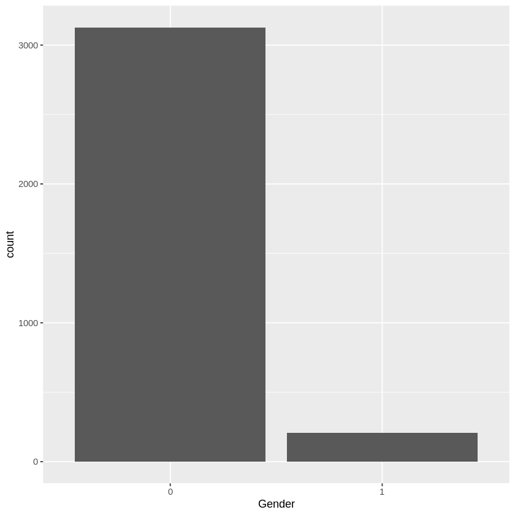

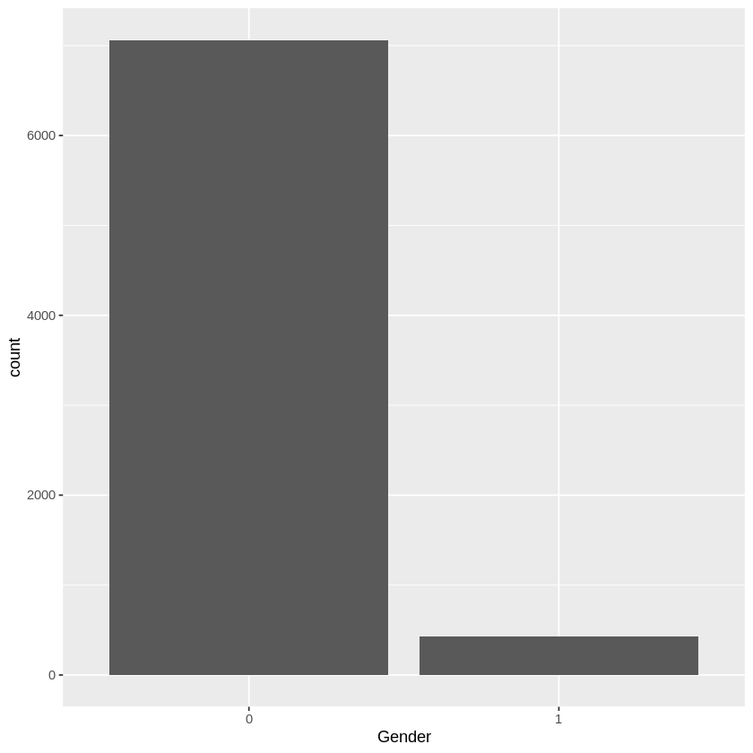

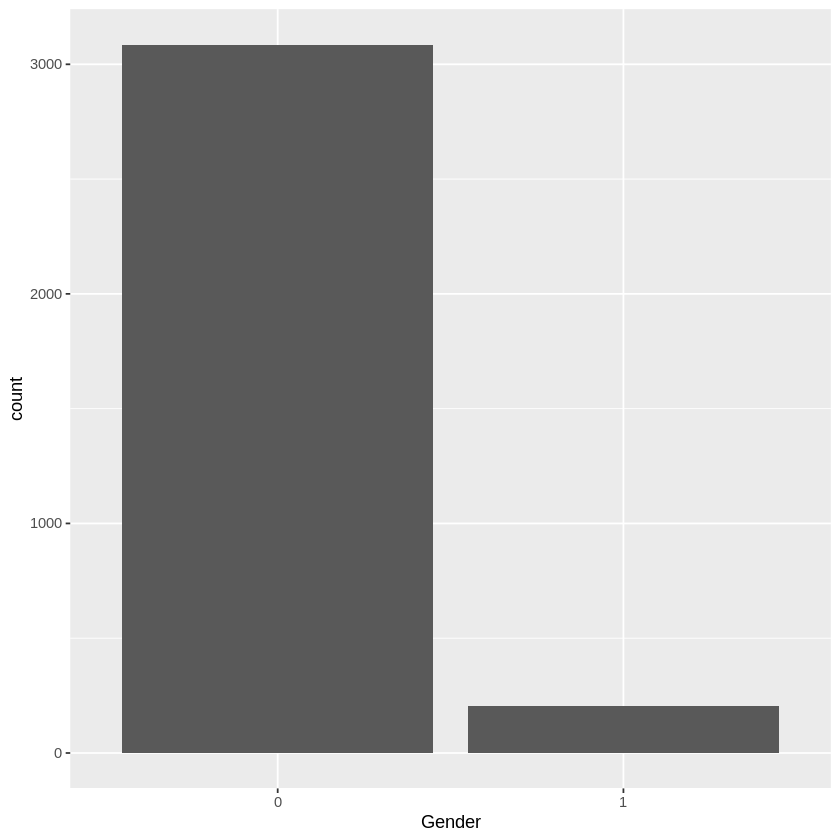

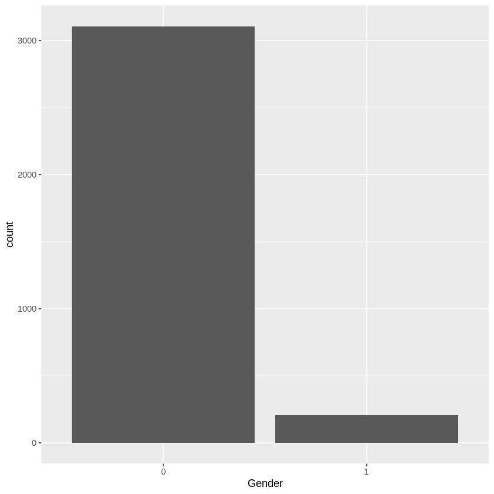

```r
ggplot(data.frame(data2004_clean), aes(x=Gender,)) +
  geom_bar()
  ggplot(data.frame(data2009_clean), aes(x=Gender,)) +
  geom_bar()
  ggplot(data.frame(data2014_clean), aes(x=Gender,)) +
  geom_bar()
  ggplot(data.frame(data2019_clean), aes(x=Gender,)) +
  geom_bar()
```

## 4) Adaptation

4.1) We need a column Equity for our datasets which will help us understand the holdings of the candidate which let's us know how stable the party will be.

```r
equity2004 <- c(data2004_clean$Total.Assets - data2004_clean$Liabilities)
equity2009 <- c(data2009_clean$Total.Assets - data2009_clean$Liabilities)
equity2014 <- c(data2014_clean$Total.Assets - data2014_clean$Liabilities)
equity2019 <- c(data2019_clean$Total.Assets - data2019_clean$Liabilities)
```

```r
data2004_clean <- cbind(data2004_clean , Equity = equity2004)
data2009_clean <- cbind(data2009_clean , Equity = equity2009)
data2014_clean <- cbind(data2014_clean , Equity = equity2014)
data2019_clean <- cbind(data2019_clean , Equity = equity2019)
```

```r
data2004_clean[1:5,]
data2009_clean[1:5,]
data2014_clean[1:5,]
data2019_clean[1:5,]
```

A data.frame: 5 × 11

|  | Candidate.Name <chr> | Party <chr> | Criminal.Cases <int> | Highest.Qualification <chr> | Age <int> | Total.Assets <dbl> | Constituency <chr> | Liabilities <int> | Winner <int> | Gender <chr> | Equity <dbl> |
| --- | --- | --- | --- | --- | --- | --- | --- | --- | --- | --- | --- |
| 1 | Manoranjan Bhakta | INC | 0 | Post Graduate | 65 | 5926740 | Andaman & Nicobar Islands | 272061 | 1 | 0 | 5654679 |
| 2 | A K Biswas | BSP | 0 | Graduate | 61 | 7876500 | Andaman & Nicobar Islands | 65000 | 0 | 0 | 7811500 |
| 3 | Asit Baran Dutta | IND | 0 | Graduate | 50 | 3070000 | Andaman & Nicobar Islands | 0 | 0 | 0 | 3070000 |
| 4 | Bishnu Pada Ray | BJP | 0 | Graduate | 54 | 1250619 | Andaman & Nicobar Islands | 128710 | 0 | 0 | 1121909 |
| 5 | Deepak Biswas | IND | 0 | Not Given | 28 | 3000 | Andaman & Nicobar Islands | 0 | 0 | 0 | 3000 |

A data.frame: 5 × 11

|  | Candidate.Name <chr> | Party <chr> | Criminal.Cases <int> | Highest.Qualification <chr> | Age <int> | Total.Assets <dbl> | Constituency <chr> | Liabilities <int> | Winner <int> | Gender <chr> | Equity <dbl> |
| --- | --- | --- | --- | --- | --- | --- | --- | --- | --- | --- | --- |
| 1 | Shri Bishnu Pada Ray | BJP | 1 | Graduate | 59 | 1241034 | Andaman & Nicobar Islands | 0 | 0 | 0 | 1241034 |
| 2 | Shri P. R. Ganeshan | RJD | 0 | Not Given | 71 | 329563 | Andaman & Nicobar Islands | 0 | 0 | 0 | 329563 |
| 3 | Shri Pradeep Kumar Ekka | JDP | 0 | Others | 37 | 410000 | Andaman & Nicobar Islands | 0 | 0 | 0 | 410000 |
| 4 | Shri T. Ali | IND | 0 | 12th Pass | 37 | 445957 | Andaman & Nicobar Islands | 296000 | 0 | 0 | 149957 |
| 5 | Shri Tapan Kumar Bepari | CPM | 0 | Post Graduate | 52 | 3986000 | Andaman & Nicobar Islands | 0 | 0 | 0 | 3986000 |

A data.frame: 5 × 11

|  | Candidate.Name <chr> | Party <chr> | Criminal.Cases <int> | Highest.Qualification <chr> | Age <int> | Total.Assets <dbl> | Constituency <chr> | Liabilities <int> | Winner <int> | Gender <chr> | Equity <dbl> |
| --- | --- | --- | --- | --- | --- | --- | --- | --- | --- | --- | --- |
| 1 | Manoranjan Bhakta | INC | 0 | Post Graduate | 65 | 5926740 | Andaman & Nicobar Islands | 272061 | 1 | 0 | 5654679 |
| 2 | A K Biswas | BSP | 0 | Graduate | 61 | 7876500 | Andaman & Nicobar Islands | 65000 | 0 | 0 | 7811500 |
| 3 | Asit Baran Dutta | IND | 0 | Graduate | 50 | 3070000 | Andaman & Nicobar Islands | 0 | 0 | 0 | 3070000 |
| 4 | Bishnu Pada Ray | BJP | 0 | Graduate | 54 | 1250619 | Andaman & Nicobar Islands | 128710 | 0 | 0 | 1121909 |
| 5 | Deepak Biswas | IND | 0 | Not Given | 28 | 3000 | Andaman & Nicobar Islands | 0 | 0 | 0 | 3000 |

A data.frame: 5 × 11

|  | Candidate.Name <chr> | Party <chr> | Criminal.Cases <int> | Highest.Qualification <chr> | Age <int> | Total.Assets <dbl> | Constituency <chr> | Liabilities <int> | Winner <int> | Gender <chr> | Equity <dbl> |
| --- | --- | --- | --- | --- | --- | --- | --- | --- | --- | --- | --- |
| 1 | Manoranjan Bhakta | INC | 0 | Post Graduate | 65 | 5926740 | Andaman & Nicobar Islands | 272061 | 1 | 0 | 5654679 |
| 2 | A K Biswas | BSP | 0 | Graduate | 61 | 7876500 | Andaman & Nicobar Islands | 65000 | 0 | 0 | 7811500 |
| 3 | Asit Baran Dutta | IND | 0 | Graduate | 50 | 3070000 | Andaman & Nicobar Islands | 0 | 0 | 0 | 3070000 |
| 4 | Bishnu Pada Ray | BJP | 0 | Graduate | 54 | 1250619 | Andaman & Nicobar Islands | 128710 | 0 | 0 | 1121909 |
| 5 | Deepak Biswas | IND | 0 | Not Given | 28 | 3000 | Andaman & Nicobar Islands | 0 | 0 | 0 | 3000 |

```r
score2004 <- runif(3334,1,99)
```

```r
data2004_clean <- cbind(data2004_clean , Score = score2004)
```

```r
score2009 <- runif(7489,1,99)
```

```r
data2009_clean <- cbind(data2009_clean , Score = score2009)
```

```r
score2014 <- runif(3290,1,99)
```

```r
data2014_clean <- cbind(data2014_clean , Score = score2014)
```

```r
score2019 <- runif(3314,1,99)
```

```r
data2019_clean <- cbind(data2019_clean , Score = score2019)
```

## 5) Descriptive Visualisation

5.1 Comparison of the candidacy representation

3128

352

206

33

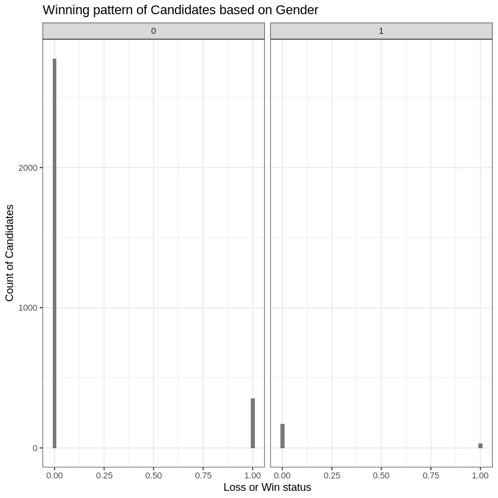

```r
sum(data2004_clean$Gender==0)
sum(data2004_clean$Gender==0 & data2004_clean$Winner)

sum(data2004_clean$Gender==1)
sum(data2004_clean$Gender==1 & data2004_clean$Winner)

ggplot(data2004_clean,
       mapping = aes(x = Winner ,)) +
  geom_histogram(alpha = 0.8, bins = 50) +
  labs(x = "Loss or Win status", y = "Count of Candidates",
       title = "Winning pattern of Candidates based on Gender") +
  facet_grid(. ~ Gender) +
  theme_bw()
```

The above code depicts the following visualization: The total male candidates were 3128 and 352 of them won their candidacy. Whereas, total female candidates were 206 and 33 of them won their candidacy. Also, if we look at the graph we can clearly see how females are under-represented. The left portion of the graph shows the winning comparison of male candidates and the right portion shoes the winning comparison of women candidates

7063

315

426

45

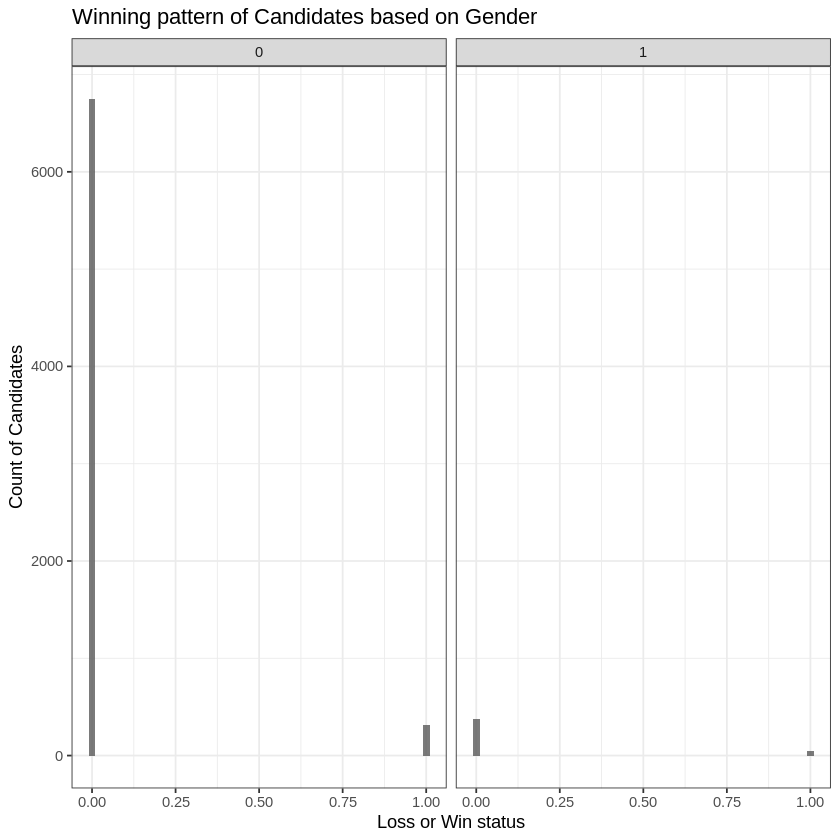

```r
sum(data2009_clean$Gender==0)
sum(data2009_clean$Gender==0 & data2009_clean$Winner)

sum(data2009_clean$Gender==1)
sum(data2009_clean$Gender==1 & data2009_clean$Winner)

ggplot(data2009_clean,
       mapping = aes(x = Winner ,)) +
  geom_histogram(alpha = 0.8, bins = 50) +
  labs(x = "Loss or Win status", y = "Count of Candidates",
       title = "Winning pattern of Candidates based on Gender") +
  facet_grid(. ~ Gender) +
  theme_bw()
```

The above code depicts the following visualization: The total male candidates were 7063 and 315 of them won their candidacy. Whereas, total female candidates were 426 and 45 of them won their candidacy. Also, if we look at the graph we can clearly see how females are under-represented. The left portion of the graph shows the winning comparison of male candidates and the right portion shoes the winning comparison of women candidates

3086

347

204

33

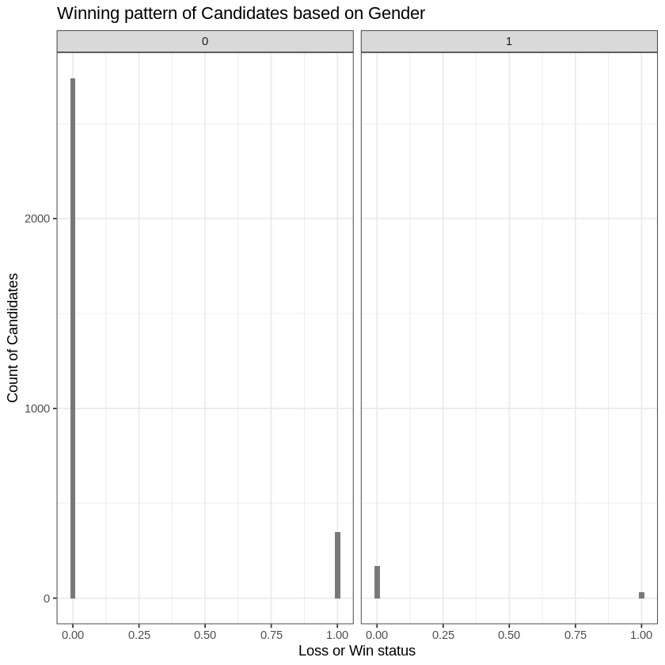

```r
sum(data2014_clean$Gender==0)
sum(data2014_clean$Gender==0 & data2014_clean$Winner)

sum(data2014_clean$Gender==1)
sum(data2014_clean$Gender==1 & data2014_clean$Winner)

ggplot(data2014_clean,
       mapping = aes(x = Winner ,)) +
  geom_histogram(alpha = 0.8, bins = 50) +
  labs(x = "Loss or Win status", y = "Count of Candidates",
       title = "Winning pattern of Candidates based on Gender") +
  facet_grid(. ~ Gender) +
  theme_bw()
```

The above code depicts the following visualization: The total male candidates were 3086 and 347 of them won their candidacy. Whereas, total female candidates were 204 and 33 of them won their candidacy. Also, if we look at the graph we can clearly see how females are under-represented. The left portion of the graph shows the winning comparison of male candidates and the right portion shoes the winning comparison of women candidates

3108

350

206

33

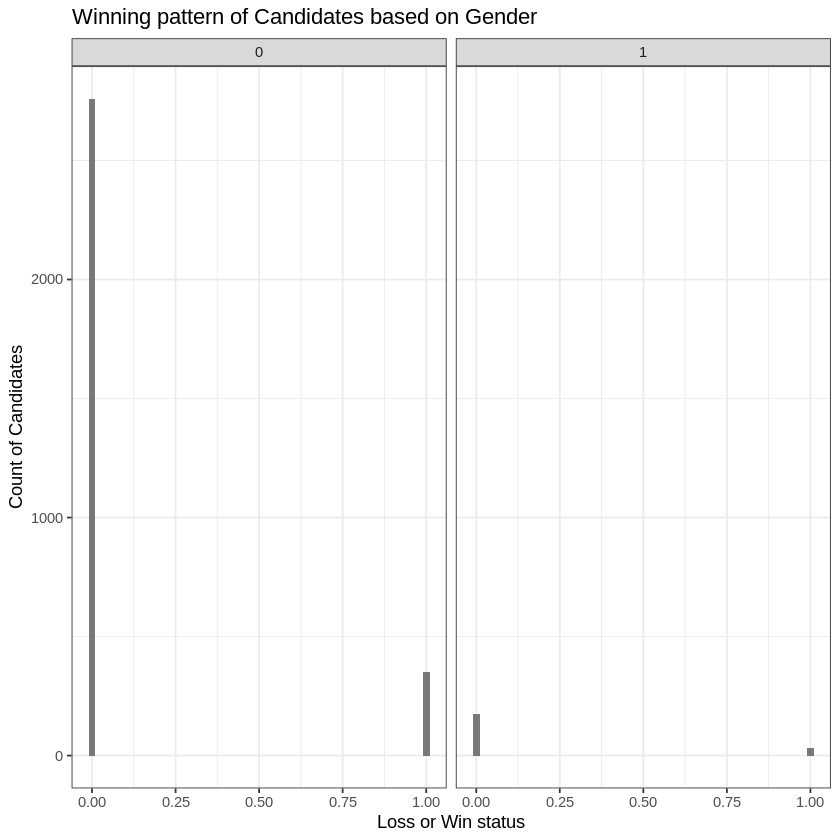

```r
sum(data2019_clean$Gender==0)
sum(data2019_clean$Gender==0 & data2019_clean$Winner)

sum(data2019_clean$Gender==1)
sum(data2019_clean$Gender==1 & data2019_clean$Winner)

ggplot(data2019_clean,
       mapping = aes(x = Winner ,)) +
  geom_histogram(alpha = 0.8, bins = 50) +
  labs(x = "Loss or Win status", y = "Count of Candidates",
       title = "Winning pattern of Candidates based on Gender") +
  facet_grid(. ~ Gender) +
  theme_bw()
```

5.2)Female representation in the whole dataset

We have plotted all the 4 datasets and have shown the female candidacy with the color pink and the male candidacy is shown in grey color.

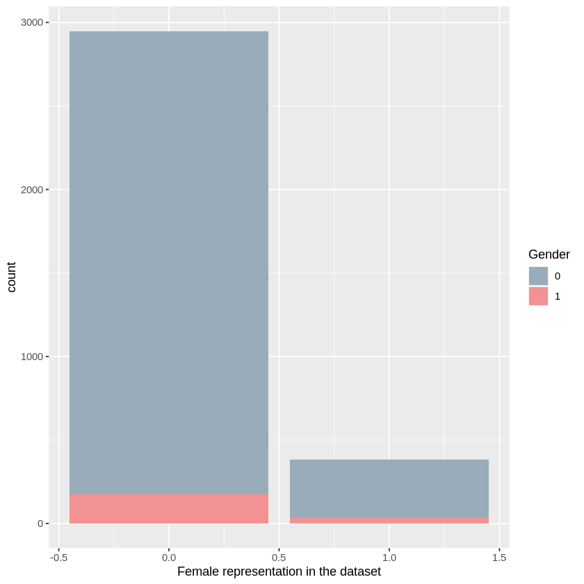

```r
ggplot(data2004_clean, aes(x = Winner , fill =Gender)) +
  geom_bar()+
  scale_fill_manual(values = c("#98adb9","#f29292")) +
  xlab("Female representation in the dataset")
```

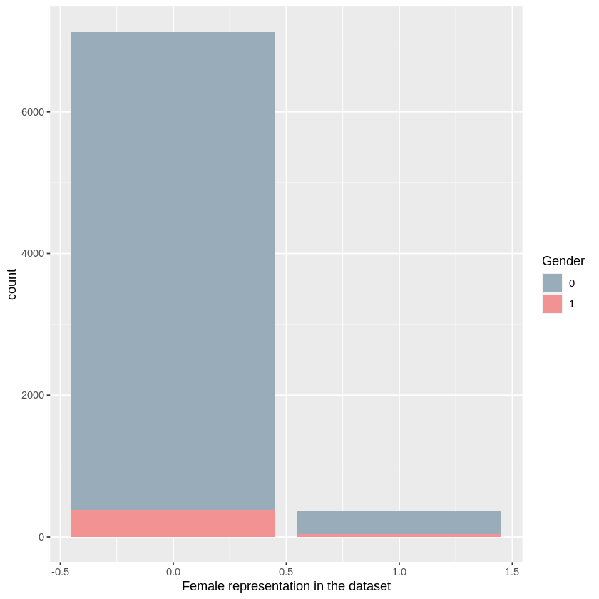

```r
ggplot(data2009_clean, aes(x = Winner , fill =Gender)) +
  geom_bar()+
  scale_fill_manual(values = c("#98adb9","#f29292")) +
  xlab("Female representation in the dataset")
```

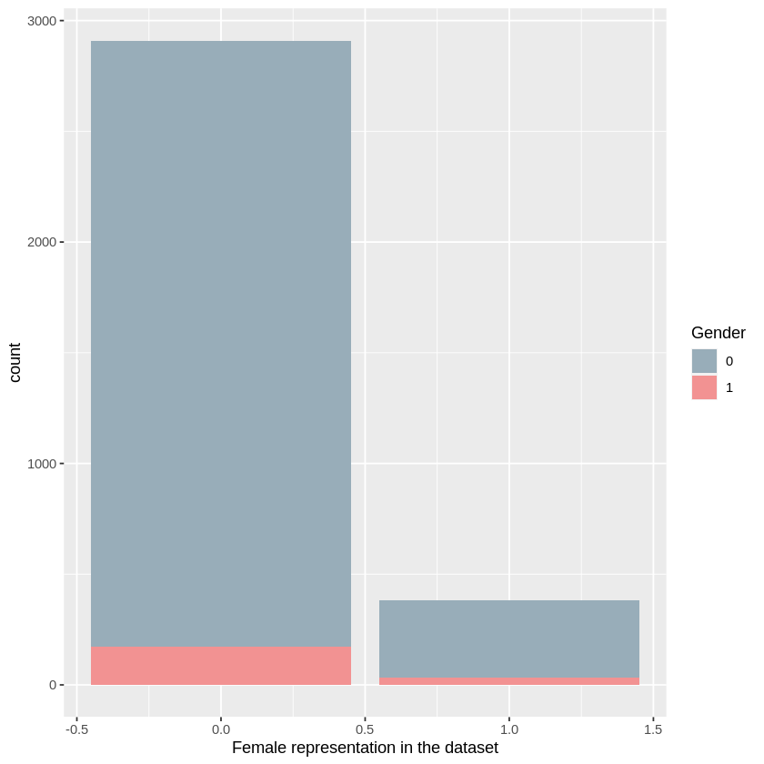

```r
ggplot(data2014_clean, aes(x = Winner , fill =Gender)) +
  geom_bar()+
  scale_fill_manual(values = c("#98adb9","#f29292")) +
  xlab("Female representation in the dataset")
```

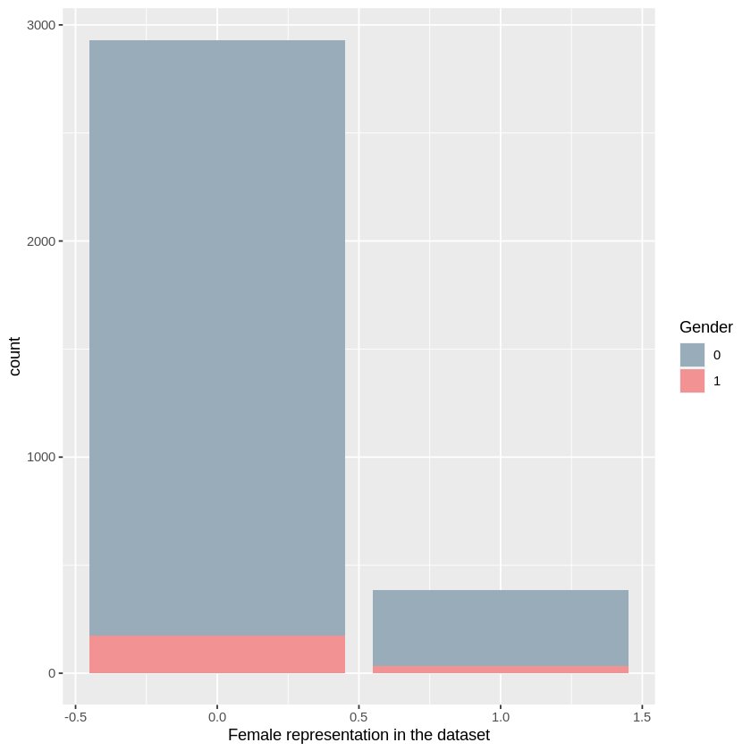

```r
ggplot(data2019_clean, aes(x = Winner , fill =Gender)) +
  geom_bar()+
  scale_fill_manual(values = c("#98adb9","#f29292")) +
  xlab("Female representation in the dataset")
```

5.3) Probability of the Age factor We wanted to represent the probability of Age in our dataset. The below line graphs show us the most probable age group for our datsets.

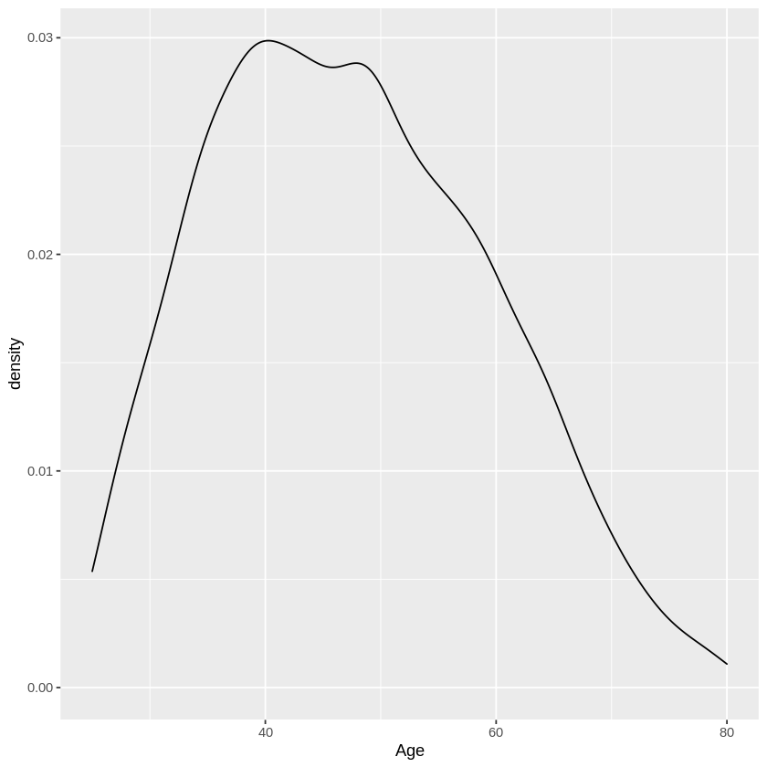

```r
ggplot(data2004_clean, aes(x = Age )) +
  geom_density()
```

So for year 2004 we can see that there were a lot of 40 year old candidates and some 46-49 year olds too. 25 and 80 year old candidates are lesser in numbers

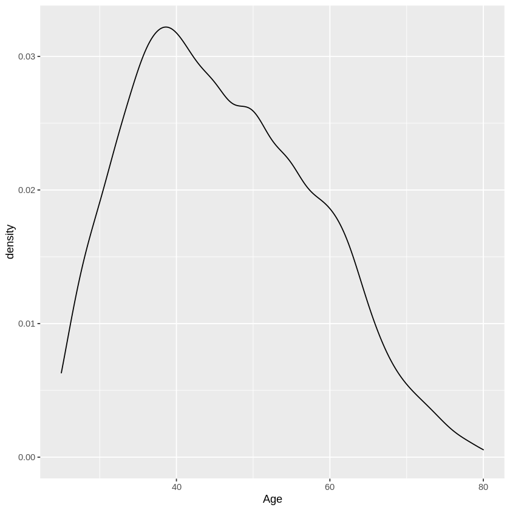

```r
ggplot(data2009_clean, aes(x = Age )) +
  geom_density()
```

So for year 2009 we can see that there were a lot of 38 year old candidates and some 42-44 year olds too. 25 and 80 year old candidates are lesser in numbers

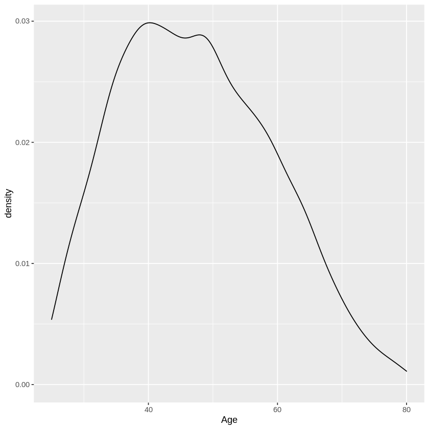

```r
ggplot(data2014_clean, aes(x = Age )) +
  geom_density()
```

So for year 2014 we can see that there were a lot of 40 year old candidates and some 46-49 year olds too. 25 and 80 year old candidates are lesser in numbers

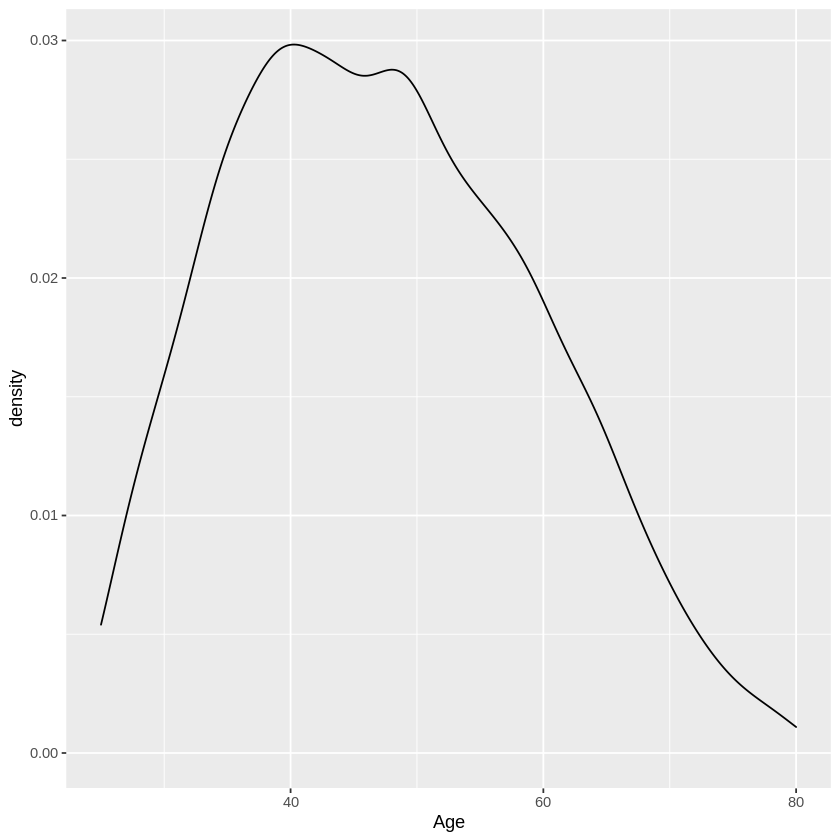

```r
ggplot(data2019_clean, aes(x = Age )) +
  geom_density()
```

5.4)We have represented criminal cases and mapped them against qualification.

Ironically we can see that most graduate candidates have a lot of criminal cases to their names.

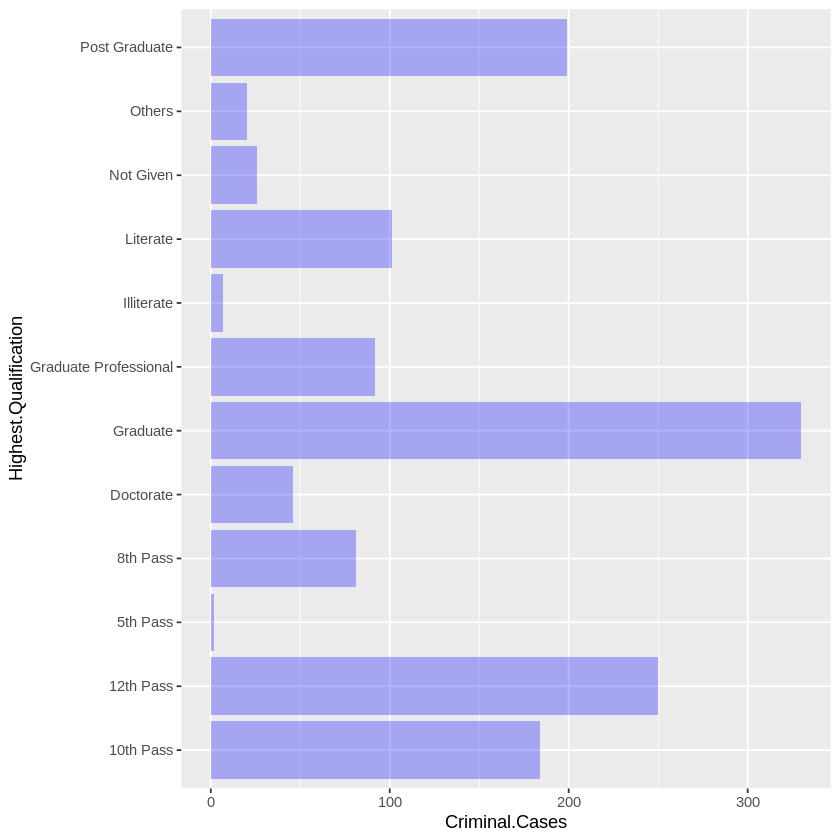

```r
ggplot(data2004_clean, aes(x = Criminal.Cases, y=Highest.Qualification)) +
geom_bar(stat="identity", fill=alpha("blue", 0.3))
```

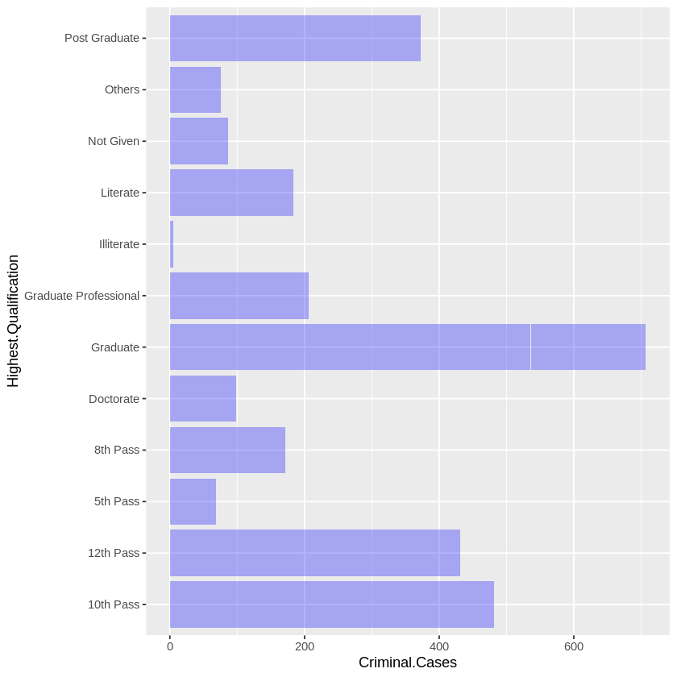

```r
ggplot(data2009_clean, aes(x = Criminal.Cases, y=Highest.Qualification)) +
geom_bar(stat="identity", fill=alpha("blue", 0.3))
```

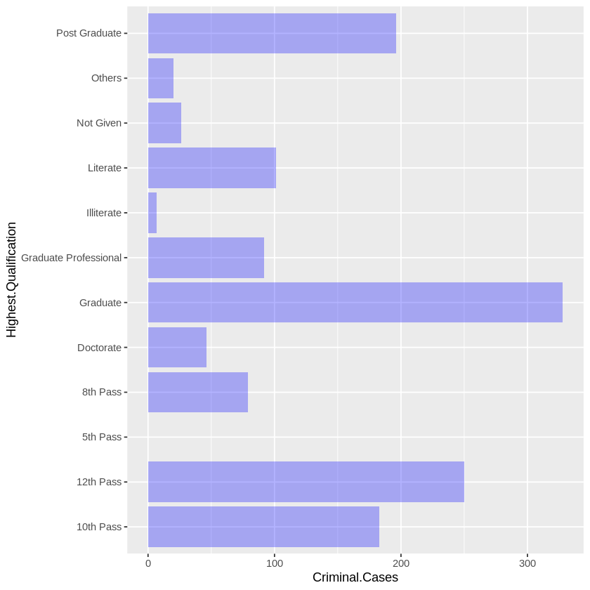

```r
ggplot(data2014_clean, aes(x = Criminal.Cases, y=Highest.Qualification)) +
geom_bar(stat="identity", fill=alpha("blue", 0.3))
```

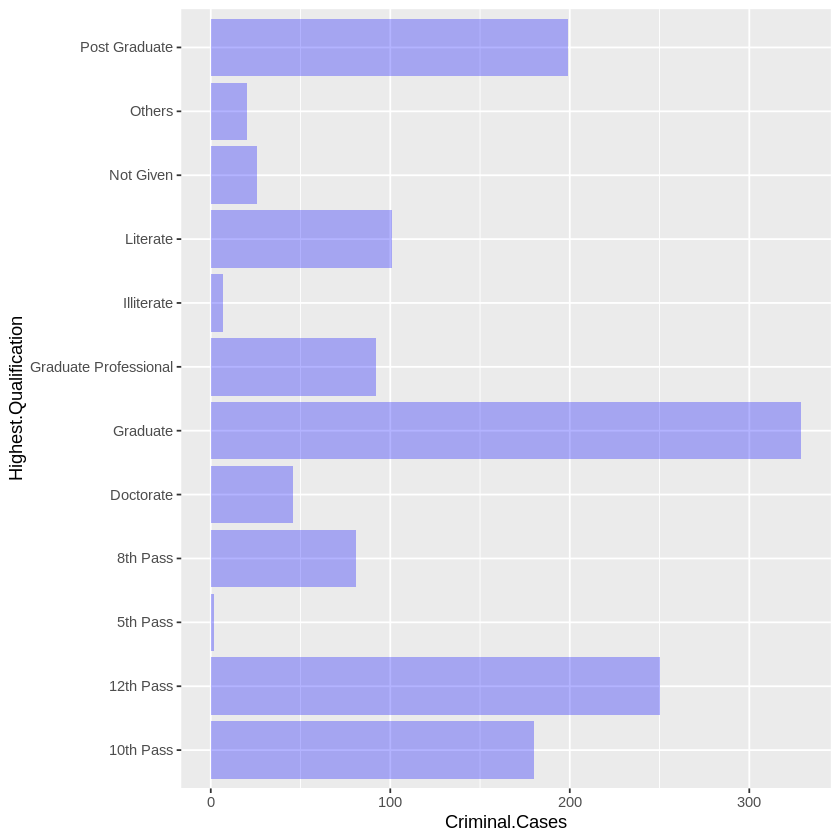

```r
ggplot(data2019_clean, aes(x = Criminal.Cases, y=Highest.Qualification)) +
geom_bar(stat="identity", fill=alpha("blue", 0.3))
```

6) Explore Correlation

[figure not shown]

```r
plot(data2004_clean$Age,data2004_clean$score2004)
```

7) Response variable

Our response variable is female representation and this shows the participation of female candidates in any Lok Sabha elections. We have chosen this variable so that we can explain our stakeholders how to improve overall female representation in the elections.

8) Simple Linear regression

Here we have compared the candidate score to the gender in our given dataset for our first simple linear regression model.

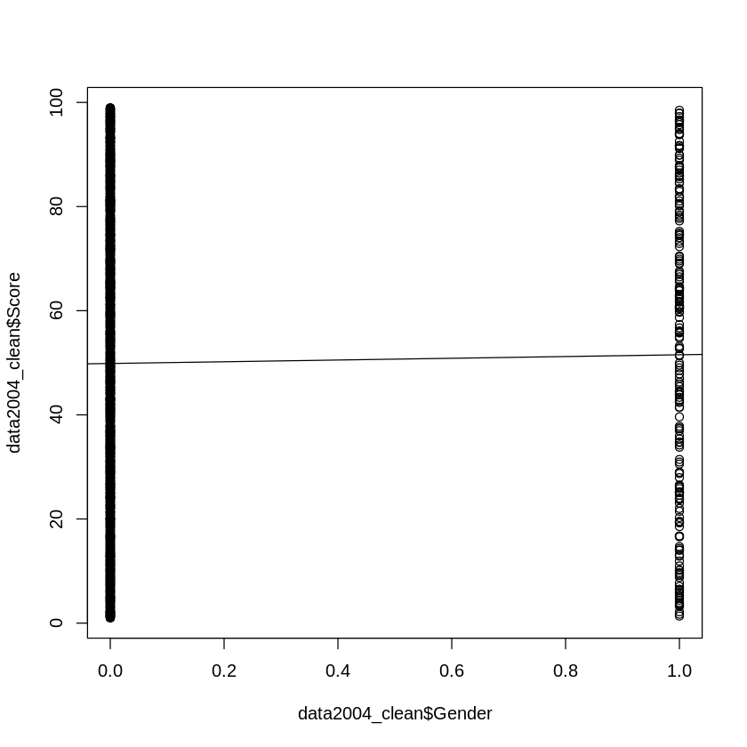

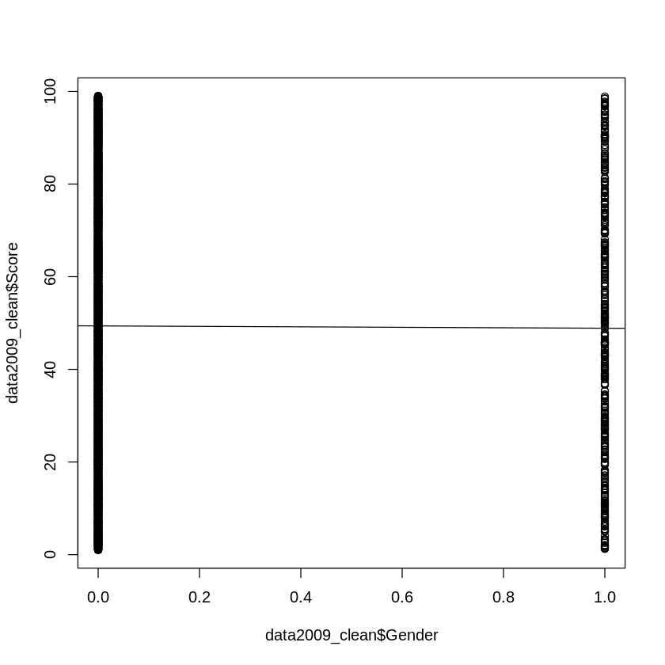

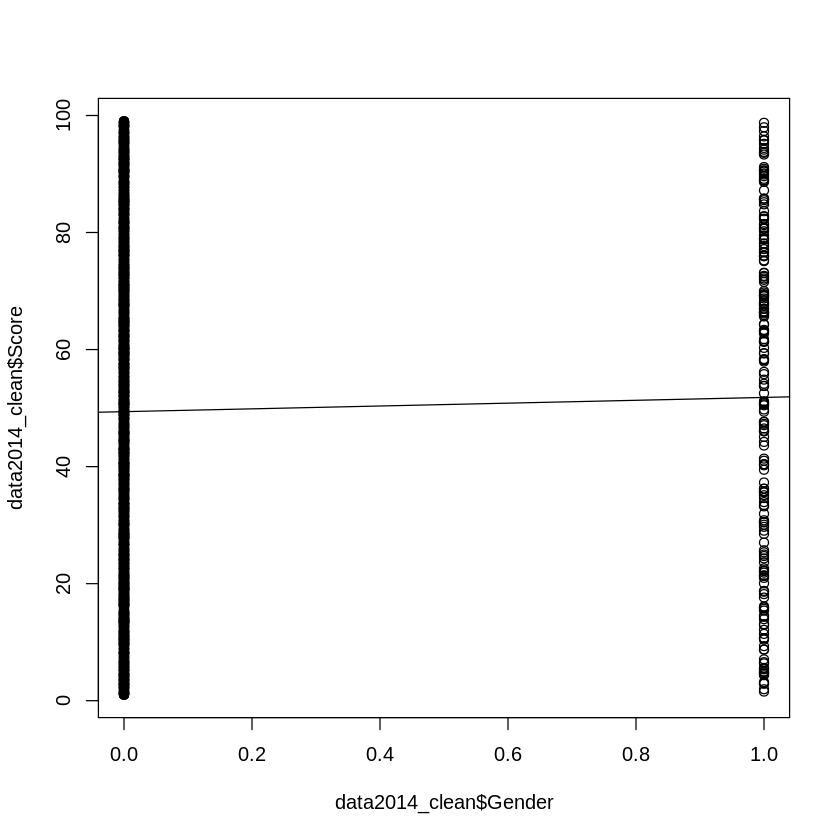

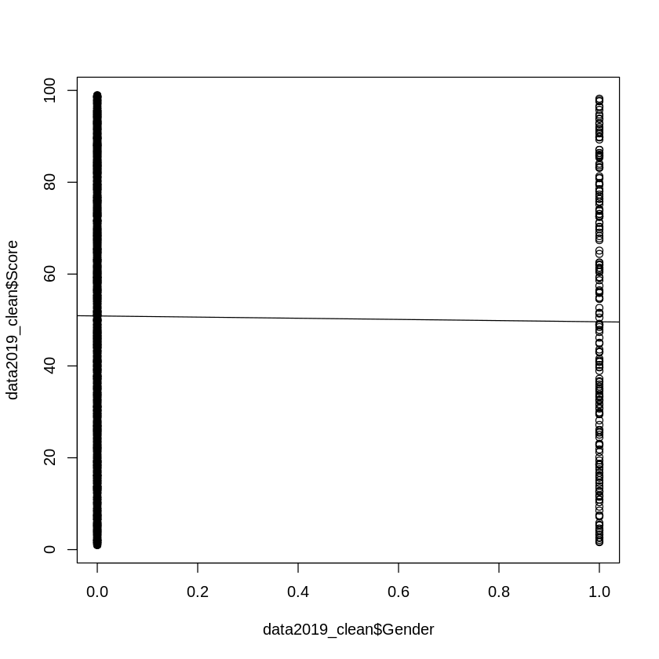

```r
plot(data2004_clean$Score ~ data2004_clean$Gender )
abline(lm(data2004_clean$Score~ data2004_clean$Gender))
plot(data2009_clean$Score ~ data2009_clean$Gender )
abline(lm(data2009_clean$Score~ data2009_clean$Gender))
plot(data2014_clean$Score ~ data2014_clean$Gender )
abline(lm(data2014_clean$Score~ data2014_clean$Gender))
plot(data2019_clean$Score ~ data2019_clean$Gender )
abline(lm(data2019_clean$Score~ data2019_clean$Gender))
```

```r
model1.1 <- lm(data2004_clean$Score ~ data2004_clean$Gender)
model1.1
model1.2 <- lm(data2009_clean$Score ~ data2009_clean$Gender)
model1.2
model1.3 <- lm(data2014_clean$Score ~ data2014_clean$Gender)
model1.3
model1.4 <- lm(data2019_clean$Score ~ data2019_clean$Gender)
model1.4
```

```
Call:
lm(formula = data2004_clean$Score ~ data2004_clean$Gender)

Coefficients:
           (Intercept)  data2004_clean$Gender1
                 49.87                    1.67
```

```
Call:
lm(formula = data2009_clean$Score ~ data2009_clean$Gender)

Coefficients:
           (Intercept)  data2009_clean$Gender1
               49.3790                 -0.5044
```

```
Call:
lm(formula = data2014_clean$Score ~ data2014_clean$Gender)

Coefficients:
           (Intercept)  data2014_clean$Gender1
                49.390                   2.434
```

```
Call:
lm(formula = data2019_clean$Score ~ data2019_clean$Gender)

Coefficients:
           (Intercept)  data2019_clean$Gender1
                50.885                  -1.271
```

Here we have compared the total liabilities of a candidate and the score of the candidate to see if there is any correlation between how well the candidate performed and the total liabilities associated with them.

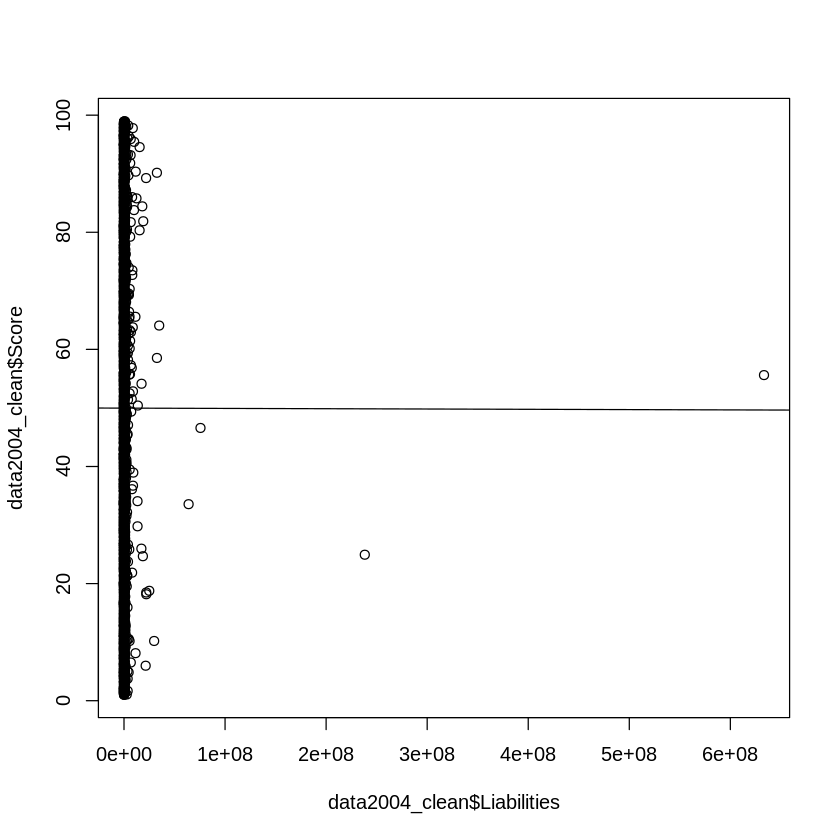

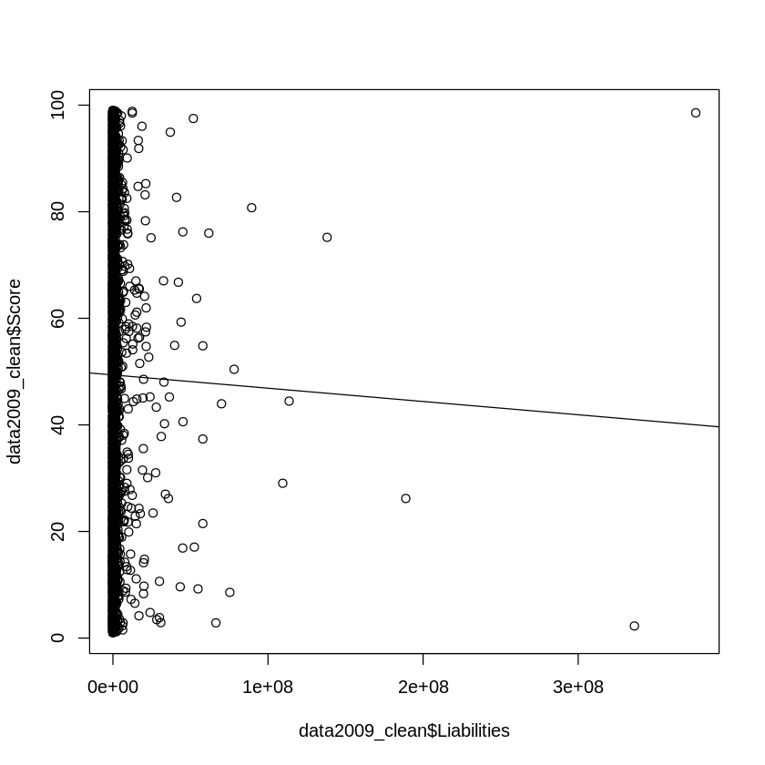

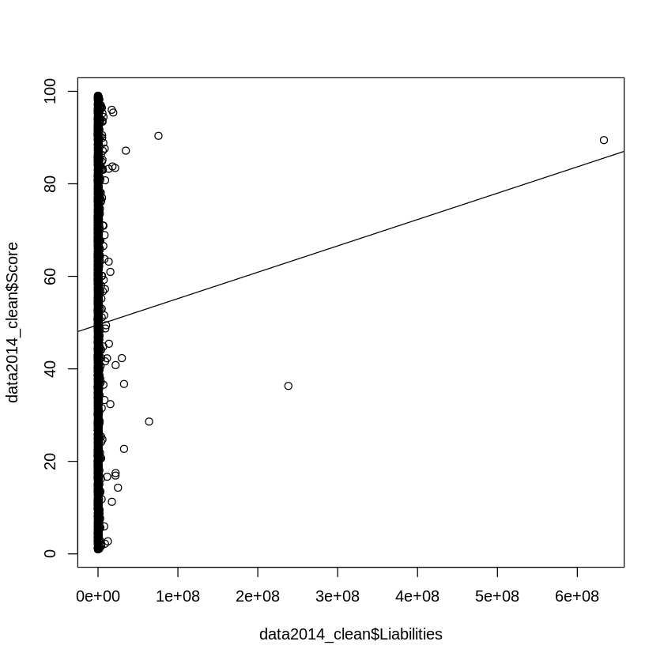

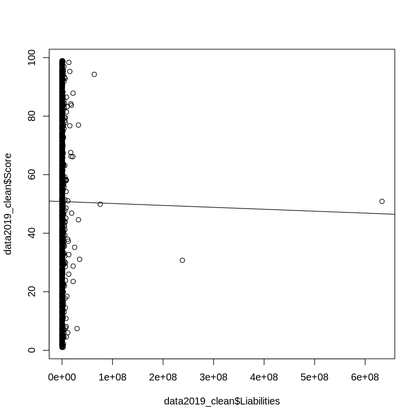

```r
plot(data2004_clean$Score ~ data2004_clean$Liabilities)
abline(lm(data2004_clean$Score~ data2004_clean$Liabilities))
plot(data2009_clean$Score ~ data2009_clean$Liabilities)
abline(lm(data2009_clean$Score~ data2009_clean$Liabilities))
plot(data2014_clean$Score ~ data2014_clean$Liabilities)
abline(lm(data2014_clean$Score~ data2014_clean$Liabilities))
plot(data2019_clean$Score ~ data2019_clean$Liabilities)
abline(lm(data2019_clean$Score~ data2019_clean$Liabilities))
```